# Proof of concept: ZDT4 (modified)

A typical stop criteria is based on the hypervolume fraction that is uncertain, i.e. an acceptance probability between 0.25 and 0.75. However, as the number of input variables increases, the number of sampled points required for an accurate Monte Carlo estimate increases. Instead, a single point-based stopping criteria is more useful; in this case, the metric is the maximum sample utility in the optimization function. When the value drops by 2 orders of magnitude, then the next point is not likely to provide much improvement.

The computational budget is (number of inputs)*10

```r
budget = 30

next.fit = start.fit
while(next.fit > start.fit*0.01 & max(GPar.all$order) < budget+Pareto.budget){
  # Create new Kriging model
  mod.dist = fill.sample.mod(GPar.data = GPar.all, input.name = c('x1', 'x2', 'x3'), output.name = 'dist')

  # Run the optimization to find the best point
  GA.pred = ga(type = 'real-valued',
               fitness = function(x){fill.sample.delta(x, model = mod.dist)},
               lower = c(0, 0, 0), upper = c(1, 1, 1),
               popSize = 50, maxiter = 50, run = 10, monitor = FALSE,
               parallel = 2)

  # Next point to sample is the solution to this optimization.
  # Account for the possibility that the genetic algorithm converges on multiple equivalent points
  point.next = GA.pred@solution[1,]

  # Find values of the selected point
  GPar.new = data.frame(x1 = point.next[1], x2 = point.next[2], x3 = point.next[3])
  res = ZDT4.mod(x = as.matrix(GPar.new))
  GPar.new$f1 = res[,1]; GPar.new$f2 = res[,2]

  # Fill in the remaining calculations: normalized outputs, distance, theta, order
  res = fill.sample.update(GPar.front.old = GPar.front, GPar.data = GPar.all, GPar.new = GPar.new)
  GPar.front = res$front
  GPar.all = res$data
  rm(res)

  # The cutoff point for the loop is 20 additional points or when the
  # fitness value is less than 1% of this starting fitness value
  next.fit = max(GA.pred@fitness)
}

# Save the data for later
write.csv(GPar.all, 'GPar_Accept_Delta1.csv')

rm(point.next)
```

```r
# Plot results on top of the most recent Kriging model
GPar.all = read.csv(file = 'GPar_Accept_Delta1.csv')
mod.dist = fill.sample.mod(GPar.data = GPar.all, input.name = c('x1', 'x2', 'x3'), output.name = 'dist')

lower = c(0, 0.3, 0); upper = c(1, 0.7, 1)
fine.grid = expand.grid(x1 = seq(from = lower[1], to = upper[1], length.out = 50),
                        x3 = c(GPar.new$x3),
                        # x3 = c(0, 0.01, 0.1, 0.5, 1))
                        x2 = c(seq(from = lower[3], to = upper[3], length.out = 50)))
fine.grid = fine.grid[,1:3]
names(fine.grid) = c('x1', 'x3', 'x2')
# Apply Kriging function of distance
res = predict(object = mod.dist, newdata = fine.grid, type = "UK")
fine.grid$dist.mean = res$mean
fine.grid$dist.sd = res$sd

# Probability that the distance is less than 1
fine.grid$dist.p1 = pnorm(q = 0, mean = fine.grid$dist.mean - 2, sd = fine.grid$dist.sd)
fine.grid$uncert = fine.grid$dist.p1*(1-fine.grid$dist.p1)+1e-10
ncolor = 7
g1 = ggplot(fine.grid) +
  geom_contour_filled(mapping = aes(x = x1, y = x2, color = uncert, z = uncert),
                      breaks = seq(from = 0, to = 0.25, length.out = ncolor), alpha = 0.5) +
  geom_point(data = GPar.all, mapping = aes(x = x1, y = x2, color = order), size = 1.5, alpha = 0.5) +
  geom_point(data = GPar.new, mapping = aes(x = x1, y = x2), color = 'red', size = 3) +
  guides(color = FALSE) +
  scale_x_continuous(expand = c(0, 0)) + scale_y_continuous(expand = c(0, 0)) +
  scale_fill_brewer(labels = c("Low", rep("", ncolor-3), "High"), palette = "PuOr")  +
  labs(x = '', y = 'x2', title = 'Uncertainty')
```

```
`guides(<scale> = FALSE)` is deprecated. Please use `guides(<scale> = "none")` instead.
```

```r
rng = range(fine.grid$dist.sd)
g2 = ggplot(fine.grid) +
  geom_contour_filled(mapping = aes(x = x1, y = x2, color = dist.sd, z = dist.sd),
                      breaks = seq(from = rng[1]*0.99, to = rng[2]*1.01, length.out = ncolor), alpha = 0.5) +
  geom_point(data = GPar.all, mapping = aes(x = x1, y = x2, color = order), size = 1.5, alpha = 0.5) +
  geom_point(data = GPar.new, mapping = aes(x = x1, y = x2), color = 'red', size = 3) +
  guides(color = FALSE) +
  scale_x_continuous(expand = c(0, 0)) + scale_y_continuous(expand = c(0, 0)) +
  scale_fill_brewer(labels = c("Low", rep("", ncolor-3), "High"), palette = "PuOr")  +
  labs(x = 'x1', y = '', title = 'Information Gain')
```

```
`guides(<scale> = FALSE)` is deprecated. Please use `guides(<scale> = "none")` instead.
```

```r
rng = range(fine.grid$dist.sd*fine.grid$uncert)
g3 = ggplot(fine.grid) +
  geom_contour_filled(mapping = aes(x = x1, y = x2, color = uncert*dist.sd, z = uncert*dist.sd),
                      breaks = seq(from = rng[1]*0.99, to = rng[2]*1.01, length.out = ncolor), alpha = 0.5) +
  geom_point(data = GPar.all, mapping = aes(x = x1, y = x2, color = order), size = 1.5, alpha = 0.5) +
  geom_point(data = GPar.new, mapping = aes(x = x1, y = x2), color = 'red', size = 3) +
  guides(color = FALSE) +
  scale_x_continuous(expand = c(0, 0)) + scale_y_continuous(expand = c(0, 0)) +
  scale_fill_brewer(labels = c("Low", rep("", ncolor-3), "High"), palette = "PuOr",  name = '')  +
  labs(x = '', y = '', title = 'Sample Utility')
```

```
`guides(<scale> = FALSE)` is deprecated. Please use `guides(<scale> = "none")` instead.
```

```
`guides(<scale> = FALSE)` is deprecated. Please use `guides(<scale> = "none")` instead.`guides(<scale> = FALSE)` is deprecated. Please use `guides(<scale> = "none")` instead.
```

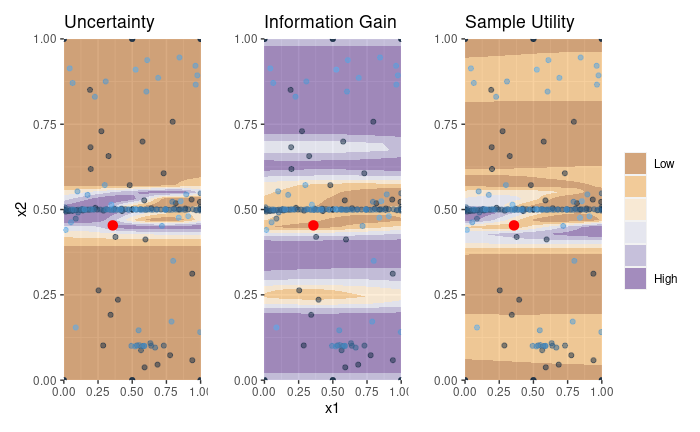

```r
(g1 + guides(fill = FALSE)) + (g2 + guides(fill = FALSE)) + g3
```

```r
## x3 slices
lower = c(0, 0.3, 0); upper = c(1, 0.7, 1)
fine.grid = expand.grid(x1 = seq(from = lower[1], to = upper[1], length.out = 50),
                        x2 = c(GPar.new$x2),
                        # x3 = c(0, 0.01, 0.1, 0.5, 1))
                        x3 = c(seq(from = lower[3], to = upper[3], length.out = 50)))
fine.grid = fine.grid[,1:3]
names(fine.grid) = c('x1', 'x2', 'x3')
# Apply Kriging function of distance
res = predict(object = mod.dist, newdata = fine.grid, type = "UK")
fine.grid$dist.mean = res$mean
fine.grid$dist.sd = res$sd

# Probability that the distance is less than 1
fine.grid$dist.p1 = pnorm(q = 0, mean = fine.grid$dist.mean - 2, sd = fine.grid$dist.sd)
fine.grid$uncert = fine.grid$dist.p1*(1-fine.grid$dist.p1)+1e-10
ncolor = 7
g1 = ggplot(fine.grid) +
  geom_contour_filled(mapping = aes(x = x1, y = x3, color = uncert, z = uncert),
                      breaks = seq(from = 0, to = 0.25, length.out = ncolor), alpha = 0.5) +
  geom_point(data = GPar.all, mapping = aes(x = x1, y = x3, color = order), size = 1.5, alpha = 0.5) +
  geom_point(data = GPar.new, mapping = aes(x = x1, y = x3), color = 'red', size = 3) +
  guides(color = FALSE) +
  scale_x_continuous(expand = c(0, 0)) + scale_y_continuous(expand = c(0, 0)) +
  scale_fill_brewer(labels = c("Low", rep("", ncolor-3), "High"), palette = "PuOr")  +
  labs(x = '', y = 'x3', title = 'Uncertainty')
```

```
`guides(<scale> = FALSE)` is deprecated. Please use `guides(<scale> = "none")` instead.
```

```r
rng = range(fine.grid$dist.sd)
g2 = ggplot(fine.grid) +
  geom_contour_filled(mapping = aes(x = x1, y = x3, color = dist.sd, z = dist.sd),
                      breaks = seq(from = rng[1]*0.99, to = rng[2]*1.01, length.out = ncolor), alpha = 0.5) +
  geom_point(data = GPar.all, mapping = aes(x = x1, y = x3, color = order), size = 1.5, alpha = 0.5) +
  geom_point(data = GPar.new, mapping = aes(x = x1, y = x3), color = 'red', size = 3) +
  guides(color = FALSE) +
  scale_x_continuous(expand = c(0, 0)) + scale_y_continuous(expand = c(0, 0)) +
  scale_fill_brewer(labels = c("Low", rep("", ncolor-3), "High"), palette = "PuOr")  +
  labs(x = 'x1', y = '', title = 'Information Gain')
```

```
`guides(<scale> = FALSE)` is deprecated. Please use `guides(<scale> = "none")` instead.
```

```r
rng = range(fine.grid$dist.sd*fine.grid$uncert)
g3 = ggplot(fine.grid) +
  geom_contour_filled(mapping = aes(x = x1, y = x3, color = uncert*dist.sd, z = uncert*dist.sd),
                      breaks = seq(from = rng[1]*0.99, to = rng[2]*1.01, length.out = ncolor), alpha = 0.5) +
  geom_point(data = GPar.all, mapping = aes(x = x1, y = x3, color = order), size = 1.5, alpha = 0.5) +
  geom_point(data = GPar.new, mapping = aes(x = x1, y = x3), color = 'red', size = 3) +
  guides(color = FALSE) +
  scale_x_continuous(expand = c(0, 0)) + scale_y_continuous(expand = c(0, 0)) +
  scale_fill_brewer(labels = c("Low", rep("", ncolor-3), "High"), palette = "PuOr", name = '')  +
  labs(x = '', y = '', title = 'Sample Utility')
```

```
`guides(<scale> = FALSE)` is deprecated. Please use `guides(<scale> = "none")` instead.
```

```
`guides(<scale> = FALSE)` is deprecated. Please use `guides(<scale> = "none")` instead.`guides(<scale> = FALSE)` is deprecated. Please use `guides(<scale> = "none")` instead.
```

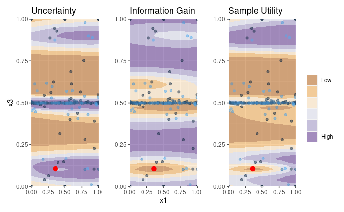

```r
(g1 + guides(fill = FALSE)) + (g2 + guides(fill = FALSE)) + g3
```

```r
rm(g1, g2, g3, fine.grid)
```

## III. Feature importance of each input variable

7. Calculate the conditional probability that a point will fall within the near-Pareto set given only information about that input variable.

The conditional probability is calculated by marginalization of the GP probabilities. From the GP, the value of P[accept | $x_1, x_2, x_3$] can be calculated, and the relationship between P[accept | $x_1, x_2, x_3$] and P[accept | $x_1$] is the integral:

P[accept | $x_1$] = integral( P[accept | $x_1, x_2, x_3$] P[$x_2$] P[$x_3$] $dx_3$ $dx_2$ )

In the absence of data to inform the distribution of $x_2$ or $x_3$, this distribution is set as a uniform distribution on the range used in the optimization.

8. Calculate the variance in the probability of the 1-variable conditional probability estimate. This variance represents the contribution due to all of the other variables in question.
9. The feature importance metric is the range of the probability divided by the average of the variance. The greater the range of probabilities, the more the single variable can influence the likelihood, but this is relative to the amount that the other variables contribute.

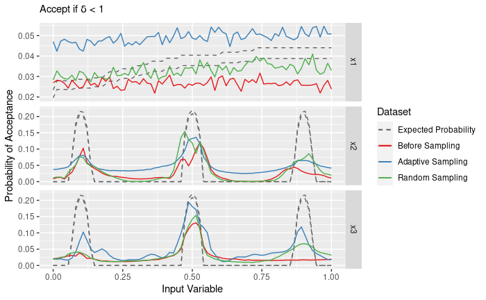

```r
# Load data: compare before/after refinement and with a random sampling for the refinement
GPar.start = read.csv(file = 'GPar_all_start.csv')
GPar.adapt = read.csv(file = 'GPar_Accept_Delta1.csv')
GPar.front = read.csv(file = 'GPar_fnt_start.csv')
# Compare to a random sample set
nsamp = nrow(GPar.adapt) - nrow(GPar.start)
GPar.rando = data.frame(x1 = runif(n = nsamp, min = 0, max = 1),
                        x2 = runif(n = nsamp, min = 0, max = 1),
                        x3 = runif(n = nsamp, min = 0, max = 1))
res = ZDT4.mod(x = as.matrix(GPar.rando))
GPar.rando$f1 = res[,1]; GPar.rando$f2 = res[,2]
# Fill in the remaining calculations: normalized outputs, distance, theta, order
GPar.rando = n.obj(GPar.data = GPar.rando, GPar.front = GPar.front)
cl <- makeCluster(2)
registerDoParallel(cl)
dist = foreach(row = 1:nrow(GPar.rando)) %dopar%
  n.dist(f1.norm = GPar.rando$f1.norm[row], f2.norm = GPar.rando$f2.norm[row], GPar.front = GPar.front)
stopCluster(cl)
GPar.rando$dist = unlist(dist)
GPar.rando$theta = atan(GPar.rando$f2.norm/GPar.rando$f1.norm)*180/pi*10/9
GPar.rando$order = seq(from = max(GPar.start$order) + 1, to = max(GPar.start$order) + nsamp, by = 1)
GPar.rando = rbind(GPar.start[, names(GPar.start) %in% names(GPar.rando)], GPar.rando)

# Construct models for each dataset
mod.dist.start = fill.sample.mod(GPar.data = GPar.start, input.name = c('x1', 'x2', 'x3'), output.name = 'dist')
mod.dist.adapt = fill.sample.mod(GPar.data = GPar.adapt, input.name = c('x1', 'x2', 'x3'), output.name = 'dist')
mod.dist.rando = fill.sample.mod(GPar.data = GPar.rando, input.name = c('x1', 'x2', 'x3'), output.name = 'dist')

# Obtain marginalized probabilities with a fine resolution grid (50 points). Calculate the integral with a Monte Carlo sampling of 1500 samples each.
Infer.dist.start = marginal.dist(mod.dist.start)
Infer.dist.adapt = marginal.dist(mod.dist.adapt)
Infer.dist.rando = marginal.dist(mod.dist.rando)

# Compare to true marginal
delta.tru = read.csv('ExpectedMarginal_delta.csv')

ggplot() +
  geom_path(data = delta.tru,        mapping = aes(x = x, y = prob+psd, color = 'tru'), linetype = 2) +
  geom_path(data = delta.tru,        mapping = aes(x = x, y = prob-psd, color = 'tru'), linetype = 2) +
  geom_path(data = Infer.dist.start, mapping = aes(x = x, y = prob, color = 'start')) +
  geom_path(data = Infer.dist.adapt, mapping = aes(x = x, y = prob, color = 'adapt')) +
  geom_path(data = Infer.dist.rando, mapping = aes(x = x, y = prob, color = 'rando')) +
  facet_grid(var~., scales = 'free_y') +
  labs(x = 'Input Variable', y = 'Probability of Acceptance', subtitle = expression('Accept if '*delta*' < 1'),
       color = 'Dataset') +
  scale_color_manual(labels = c('tru' = 'Expected Probability',
                                  'start' = 'Before Sampling',
                                  'adapt' = 'Adaptive Sampling', 'rando' = 'Random Sampling'),
                       values = c('tru' = 'grey40', 'start' = '#e41a1c', 'adapt' = '#377eb8', 'rando' = '#4daf4a'),
                       breaks = c('tru', 'start', 'adapt', 'rando')) +
  guides(color = guide_legend(override.aes = list(linetype = c(2, 1, 1, 1))))
```

```r
# Coefficients of determination.
expect1 = filter(delta.tru, var == 'x1')$prob
expect2 = filter(delta.tru, var == 'x2')$prob
expect3 = filter(delta.tru, var == 'x3')$prob
data.frame(method = c('Before Sampling', 'Adaptive Sampling', 'Random Sampling'),
           R2.x1 = c(cor(x = filter(Infer.dist.start, var == 'x1')$prob, y = expect1, method = 'pearson')^2,
             cor(x = filter(Infer.dist.adapt, var == 'x1')$prob, y = expect1, method = 'pearson')^2,
             cor(x = filter(Infer.dist.rando, var == 'x1')$prob, y = expect1, method = 'pearson')^2),
           R2.x2 = c(cor(x = filter(Infer.dist.start, var == 'x2')$prob, y = expect2, method = 'pearson')^2,
             cor(x = filter(Infer.dist.adapt, var == 'x2')$prob, y = expect2, method = 'pearson')^2,
             cor(x = filter(Infer.dist.rando, var == 'x2')$prob, y = expect2, method = 'pearson')^2),
           R2.x3 = c(cor(x = filter(Infer.dist.start, var == 'x3')$prob, y = expect3, method = 'pearson')^2,
             cor(x = filter(Infer.dist.adapt, var == 'x3')$prob, y = expect3, method = 'pearson')^2,
             cor(x = filter(Infer.dist.rando, var == 'x3')$prob, y = expect3, method = 'pearson')^2)
           )
```

| method | R2.x1 | R2.x2 | R2.x3 |
| --- | --- | --- | --- |
| Before Sampling | 4.591405e-07 | 0.3845964 | 0.3089620 |
| Adaptive Sampling | 3.766866e-01 | 0.6095667 | 0.5705095 |
| Random Sampling | 4.148832e-01 | 0.4889081 | 0.5478466 |

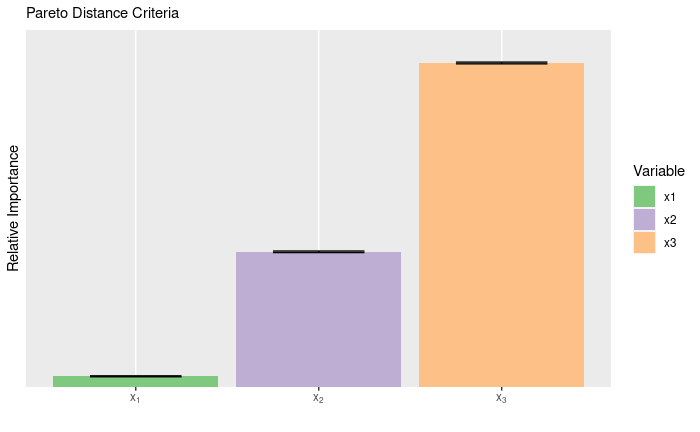

```r
# Relative importance: inverse of the area under the curve, normalized units,
# adjusted by the range of the probabilities' means
Infer.x1 = filter(Infer.dist.adapt, var == 'x1')
Infer.x2 = filter(Infer.dist.adapt, var == 'x2')
Infer.x3 = filter(Infer.dist.adapt, var == 'x3')
Import.delta = data.frame(import = c(diff(range(Infer.x1$prob))*nrow(Infer.x1)/sum(Infer.x1$psd),
                                     diff(range(Infer.x2$prob))*nrow(Infer.x2)/sum(Infer.x2$psd),
                                     diff(range(Infer.x3$prob))*nrow(Infer.x3)/sum(Infer.x3$psd)),
                          var = c('x1', 'x2', 'x3'),
                          typ = 'delta')
# Uncertainty in the calculation based on the Monte Carlo error
Import.delta$sd = sqrt(c(max(Infer.x1$prob)*(1-max(Infer.x1$prob)) + min(Infer.x1$prob)*(1-min(Infer.x1$prob)) *
                      diff(range(Infer.x1$prob)),
                    max(Infer.x2$prob)*(1-max(Infer.x2$prob)) + min(Infer.x2$prob)*(1-min(Infer.x2$prob)) *
                      diff(range(Infer.x2$prob)),
                    max(Infer.x3$prob)*(1-max(Infer.x3$prob)) + min(Infer.x3$prob)*(1-min(Infer.x3$prob)) *
                      diff(range(Infer.x3$prob)) )/1500 +
                  c(var(Infer.x1$psd), var(Infer.x2$psd), var(Infer.x3$psd))/nrow(Infer.x1) )

ggplot(Import.delta) +
  geom_col(mapping = aes(x = var, y = import, fill = var)) +
  geom_errorbar(mapping = aes(x = var, ymin = import - sd, ymax = import + sd), width = 0.5) +
  labs(x = '', y = 'Relative Importance', fill = 'Variable',
       subtitle = expression('Pareto Distance Criteria')) +
  scale_y_continuous(breaks = c(), expand = expansion(mult = c(0, .1))) +
  scale_x_discrete(labels = c(expression('x'[1]), expression('x'[2]), expression('x'[3]))) +
  scale_fill_manual(values = c('#7fc97f', '#beaed4', '#fdc086'))
```

```r
# Store the data for importance ranking comparison later
Infer.plt = rbind(Infer.x1, Infer.x2, Infer.x3);
delta.tru$cat = 'tru';          Infer.dist.start$cat = 'start'
Infer.dist.adapt$cat = 'adapt'; Infer.dist.rando$cat = 'rando'
write.csv(rbind(delta.tru[, names(delta.tru) %in% names(Infer.dist.start)],
      Infer.dist.start[, names(Infer.dist.start) %in% names(delta.tru)],
      Infer.dist.adapt[, names(Infer.dist.adapt) %in% names(delta.tru)],
      Infer.dist.rando[, names(Infer.dist.rando) %in% names(delta.tru)]), 'Marginals_delta_tru.csv')
```

## Alternative Acceptance Criteria

For the purpose of illustration, the above method will be repeated with two other acceptance criteria: * Objective function values below a specific threshold. * Within a specific normalized distance of the utopia point and a specified prioritization of the two objective functions.

### Threshold cutoff

Load the original dataset (after solving the Pareto front).

```r
# Load data
GPar.all = read.csv(file = 'GPar_all_start.csv')
GPar.front = read.csv(file = 'GPar_fnt_start.csv')

# Remove leading indices: check if the first name is x1
while(names(GPar.all)[1] != 'x1'){
  GPar.all = GPar.all[,2:length(names(GPar.all))]
}
while(names(GPar.front)[1] != 'x1'){
  GPar.front = GPar.front[,2:length(names(GPar.front))]
}
```

```r
# Search for the first point
mod.f1 = fill.sample.mod(GPar.data = GPar.all, input.name = c('x1', 'x2', 'x3'), output.name = 'f1.norm')
mod.f2 = fill.sample.mod(GPar.data = GPar.all, input.name = c('x1', 'x2', 'x3'), output.name = 'f2.norm')
GA.pred = ga(type = 'real-valued',
             fitness = function(x){fill.sample.cutof(x, model.f1 = mod.f1, model.f2 = mod.f2)},
             lower = c(0, 0, 0), upper = c(1, 1, 1),
             popSize = 100, maxiter = 100, run = 10, monitor = FALSE,
             parallel = 2)
# Next point to sample is the solution to this optimization
point.next = GA.pred@solution[1,]

# Account for the possibility that the genetic algorithm converges on multiple equivalent points
GPar.new = data.frame(x1 = point.next[1], x2 = point.next[2], x3 = point.next[3])
res = ZDT4.mod(x = as.matrix(GPar.new))
GPar.new$f1 = res[,1]; GPar.new$f2 = res[,2]
# Add point to the samples
res = fill.sample.update(GPar.front.old = GPar.front, GPar.data = GPar.all, GPar.new = GPar.new)
GPar.front = res$front
GPar.all = res$data
rm(res)
# Fitness value for iteration
start.fit = max(GA.pred@fitness)

# Store first point for plotting
GPar.new1 = GPar.new
rm(dist)

# Store the initial mod.dist for later
mod.f1.init = mod.f1
mod.f2.init = mod.f2
```

Visualize the first loop again to show that the set of the acceptable points is different due to the different criteria.

```r
lower = c(0, 0.3, 0); upper = c(1, 0.7, 1)
fine.grid = expand.grid(x1 = seq(from = lower[1], to = upper[1], length.out = 50),
                        x3 = c(GPar.new$x3),
                        # x3 = c(0, 0.01, 0.1, 0.5, 1))
                        x2 = c(seq(from = lower[3], to = upper[3], length.out = 50)))
fine.grid = fine.grid[,1:3]
names(fine.grid) = c('x1', 'x3', 'x2')
# Apply Kriging function of distance
res = predict(object = mod.f1.init, newdata = fine.grid, type = "UK")
fine.grid$f1.mean = res$mean
fine.grid$f1.sd = res$sd

res = predict(object = mod.f2.init, newdata = data.frame(x1 = fine.grid$x1,
                     x2 = fine.grid$x2, x3 = fine.grid$x3), type = "UK")
fine.grid$f2.mean = res$mean
fine.grid$f2.sd = res$sd

# Probability that the distance is less than 1
fine.grid$prob = pnorm(q = 0, mean = fine.grid$f1.mean - 2, sd = fine.grid$f1.sd) *
  pnorm(q = 0, mean = fine.grid$f2.mean - 2, sd = fine.grid$f2.sd)
fine.grid$uncert = fine.grid$prob*(1-fine.grid$prob)+1e-10

# Information gain = variance = (var1*mean2)^2 + (var2*mean1)^2
fine.grid$info = (fine.grid$f1.sd/max(fine.grid$f1.sd))^2 + (fine.grid$f2.sd/max(fine.grid$f2.sd))^2

ncolor = 7
g1 = ggplot(fine.grid) +
  geom_contour_filled(mapping = aes(x = x1, y = x2, color = uncert, z = uncert),
                      breaks = seq(from = 0, to = 0.25, length.out = ncolor), alpha = 0.5) +
  geom_point(data = GPar.new, mapping = aes(x = x1, y = x2), color = 'red', size = 3) +
  guides(color = FALSE) +
  scale_x_continuous(expand = c(0, 0)) + scale_y_continuous(expand = c(0, 0)) +
  scale_fill_brewer(labels = c("Low", rep("", ncolor-3), "High"), palette = "PuOr")  +
  labs(x = '', y = 'x2', title = 'Uncertainty')
```

```
`guides(<scale> = FALSE)` is deprecated. Please use `guides(<scale> = "none")` instead.
```

```r
rng = range(fine.grid$info)
g2 = ggplot(fine.grid) +
  geom_contour_filled(mapping = aes(x = x1, y = x2, color = info, z = info),
                      breaks = seq(from = rng[1]*0.99, to = rng[2]*1.01, length.out = ncolor), alpha = 0.5) +
  geom_point(data = GPar.new, mapping = aes(x = x1, y = x2), color = 'red', size = 3) +
  guides(color = FALSE) +
  scale_x_continuous(expand = c(0, 0)) + scale_y_continuous(expand = c(0, 0)) +
  scale_fill_brewer(labels = c("Low", rep("", ncolor-3), "High"), palette = "PuOr")  +
  labs(x = 'x1', y = '', title = 'Information Gain')
```

```
`guides(<scale> = FALSE)` is deprecated. Please use `guides(<scale> = "none")` instead.
```

```r
rng = range(fine.grid$info*fine.grid$uncert)
g3 = ggplot(fine.grid) +
  geom_contour_filled(mapping = aes(x = x1, y = x2, color = uncert*info, z = uncert*info),
                      breaks = seq(from = rng[1]*0.99, to = rng[2]*1.01, length.out = ncolor), alpha = 0.5) +
  geom_point(data = GPar.new, mapping = aes(x = x1, y = x2), color = 'red', size = 3) +
  guides(color = FALSE) +
  scale_x_continuous(expand = c(0, 0)) + scale_y_continuous(expand = c(0, 0)) +
  scale_fill_brewer(labels = c("Low", rep("", ncolor-3), "High"), palette = "PuOr",  name = '')  +
  labs(x = '', y = '', title = 'Sample Utility')
```

```
`guides(<scale> = FALSE)` is deprecated. Please use `guides(<scale> = "none")` instead.
```

```
`guides(<scale> = FALSE)` is deprecated. Please use `guides(<scale> = "none")` instead.`guides(<scale> = FALSE)` is deprecated. Please use `guides(<scale> = "none")` instead.
```

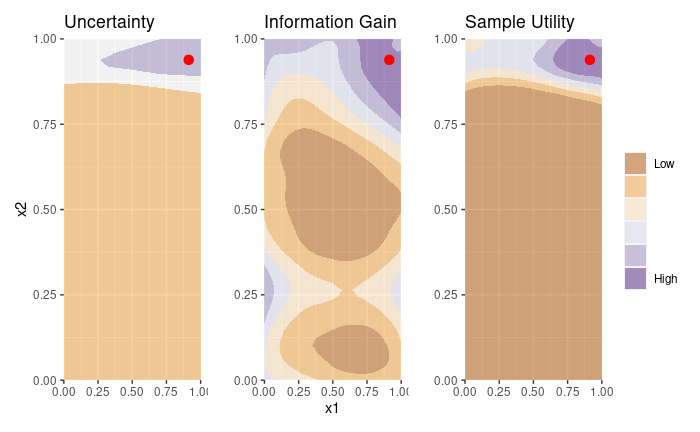

```r
(g1 + guides(fill = FALSE)) + (g2 + guides(fill = FALSE)) + g3
```

```r
## x3 slices
lower = c(0, 0.3, 0); upper = c(1, 0.7, 1)
fine.grid = expand.grid(x1 = seq(from = lower[1], to = upper[1], length.out = 50),
                        x2 = c(GPar.new$x2),
                        # x3 = c(0, 0.01, 0.1, 0.5, 1))
                        x3 = c(seq(from = lower[3], to = upper[3], length.out = 50)))
fine.grid = fine.grid[,1:3]
names(fine.grid) = c('x1', 'x2', 'x3')
# Apply Kriging function of distance
res = predict(object = mod.f1.init, newdata = fine.grid, type = "UK")
fine.grid$f1.mean = res$mean
fine.grid$f1.sd = res$sd

res = predict(object = mod.f2.init, newdata = data.frame(x1 = fine.grid$x1,
                     x2 = fine.grid$x2, x3 = fine.grid$x3), type = "UK")
fine.grid$f2.mean = res$mean
fine.grid$f2.sd = res$sd

# Probability that the distance is less than 1
fine.grid$prob = pnorm(q = 0, mean = fine.grid$f1.mean - 2, sd = fine.grid$f1.sd) *
  pnorm(q = 0, mean = fine.grid$f2.mean - 2, sd = fine.grid$f2.sd)
fine.grid$uncert = fine.grid$prob*(1-fine.grid$prob)+1e-10

# Information gain = variance = (var1*mean2)^2 + (var2*mean1)^2
fine.grid$info = (fine.grid$f1.sd/max(fine.grid$f1.sd))^2 + (fine.grid$f2.sd/max(fine.grid$f2.sd))^2

g1 = ggplot(fine.grid) +
  geom_contour_filled(mapping = aes(x = x1, y = x3, color = uncert, z = uncert),
                      breaks = seq(from = 0, to = 0.25, length.out = ncolor), alpha = 0.5) +
  geom_point(data = GPar.new, mapping = aes(x = x1, y = x3), color = 'red', size = 3) +
  guides(color = FALSE) +
  scale_x_continuous(expand = c(0, 0)) + scale_y_continuous(expand = c(0, 0)) +
  scale_fill_brewer(labels = c("Low", rep("", ncolor-3), "High"), palette = "PuOr")  +
  labs(x = '', y = 'x3', title = 'Uncertainty')
```

```
`guides(<scale> = FALSE)` is deprecated. Please use `guides(<scale> = "none")` instead.
```

```r
rng = range(fine.grid$info)
g2 = ggplot(fine.grid) +
  geom_contour_filled(mapping = aes(x = x1, y = x3, color = info, z = info),
                      breaks = seq(from = rng[1]*0.99, to = rng[2]*1.01, length.out = ncolor), alpha = 0.5) +
  geom_point(data = GPar.new, mapping = aes(x = x1, y = x3), color = 'red', size = 3) +
  guides(color = FALSE) +
  scale_x_continuous(expand = c(0, 0)) + scale_y_continuous(expand = c(0, 0)) +
  scale_fill_brewer(labels = c("Low", rep("", ncolor-3), "High"), palette = "PuOr")  +
  labs(x = 'x1', y = '', title = 'Information Gain')
```

```
`guides(<scale> = FALSE)` is deprecated. Please use `guides(<scale> = "none")` instead.
```

```r
rng = range(fine.grid$info*fine.grid$uncert)
g3 = ggplot(fine.grid) +
  geom_contour_filled(mapping = aes(x = x1, y = x3, color = uncert*info, z = uncert*info),
                      breaks = seq(from = rng[1]*0.99, to = rng[2]*1.01, length.out = ncolor), alpha = 0.5) +
  geom_point(data = GPar.new, mapping = aes(x = x1, y = x3), color = 'red', size = 3) +
  guides(color = FALSE) +
  scale_x_continuous(expand = c(0, 0)) + scale_y_continuous(expand = c(0, 0)) +
  scale_fill_brewer(labels = c("Low", rep("", ncolor-3), "High"), palette = "PuOr", name = '')  +
  labs(x = '', y = '', title = 'Sample Utility')
```

```
`guides(<scale> = FALSE)` is deprecated. Please use `guides(<scale> = "none")` instead.
```

```
`guides(<scale> = FALSE)` is deprecated. Please use `guides(<scale> = "none")` instead.`guides(<scale> = FALSE)` is deprecated. Please use `guides(<scale> = "none")` instead.
```

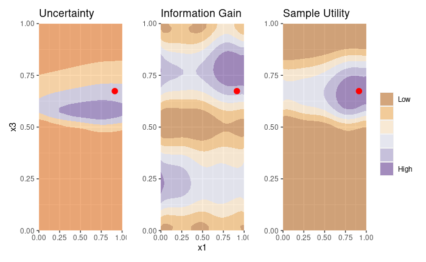

```r
(g1 + guides(fill = FALSE)) + (g2 + guides(fill = FALSE)) + g3
```

```r
rm(g1, g2, g3, fine.grid)
```

```r
budget = 30
next.fit = start.fit
while(next.fit > start.fit*0.005 & max(GPar.all$order) < budget+Pareto.budget){
  # Create a Kriging model for the distance
  mod.f1 = fill.sample.mod(GPar.data = GPar.all, input.name = c('x1', 'x2', 'x3'), output.name = 'f1.norm')
  mod.f2 = fill.sample.mod(GPar.data = GPar.all, input.name = c('x1', 'x2', 'x3'), output.name = 'f2.norm')
  GA.pred = ga(type = 'real-valued',
               fitness = function(x){fill.sample.cutof(x, model.f1 = mod.f1, model.f2 = mod.f2)},
               lower = c(0, 0, 0), upper = c(1, 1, 1),
               popSize = 100, maxiter = 100, run = 10, monitor = FALSE,
               parallel = 2)

  # Next point to sample is the solution to this optimization.
  # Account for the possibility that the genetic algorithm converges on multiple equivalent points
  point.next = GA.pred@solution[1,]

  # Find values of the selected point
  GPar.new = data.frame(x1 = point.next[1], x2 = point.next[2], x3 = point.next[3])
  res = ZDT4.mod(x = as.matrix(GPar.new))
  GPar.new$f1 = res[,1]; GPar.new$f2 = res[,2]

  # Add point to the samples
  res = fill.sample.update(GPar.front.old = GPar.front, GPar.data = GPar.all, GPar.new = GPar.new)
  GPar.front = res$front
  GPar.all = res$data
  rm(res)

  # The cutoff point for the loop is 20 additional points or when the fitness value is less than half of this starting fitness value
  next.fit = max(GA.pred@fitness)
}

write.csv(GPar.all, 'GPar_Accept_Threshold.csv')

rm(res)
```

```r
# Plot results on top of the most recent Kriging model
GPar.all = read.csv(file = 'GPar_Accept_Threshold.csv')
# Create a Kriging model for the distance
mod.f1 = fill.sample.mod(GPar.data = GPar.all, input.name = c('x1', 'x2', 'x3'), output.name = 'f1.norm')
mod.f2 = fill.sample.mod(GPar.data = GPar.all, input.name = c('x1', 'x2', 'x3'), output.name = 'f2.norm')

lower = c(0, 0.3, 0); upper = c(1, 0.7, 1)
fine.grid = expand.grid(x1 = seq(from = lower[1], to = upper[1], length.out = 50),
                        x3 = c(GPar.new$x3),
                        # x3 = c(0, 0.01, 0.1, 0.5, 1))
                        x2 = c(seq(from = lower[3], to = upper[3], length.out = 50)))
fine.grid = fine.grid[,1:3]
names(fine.grid) = c('x1', 'x3', 'x2')
# Apply Kriging function of distance
res = predict(object = mod.f1, newdata = fine.grid, type = "UK")
fine.grid$f1.mean = res$mean
fine.grid$f1.sd = res$sd

res = predict(object = mod.f2, newdata = data.frame(x1 = fine.grid$x1,
                     x2 = fine.grid$x2, x3 = fine.grid$x3), type = "UK")
fine.grid$f2.mean = res$mean
fine.grid$f2.sd = res$sd

# Probability that the distance is less than 1
fine.grid$prob = pnorm(q = 0, mean = fine.grid$f1.mean - 2, sd = fine.grid$f1.sd) *
  pnorm(q = 0, mean = fine.grid$f2.mean - 2, sd = fine.grid$f2.sd)
fine.grid$uncert = fine.grid$prob*(1-fine.grid$prob)+1e-10

# Information gain = variance = (var1*mean2)^2 + (var2*mean1)^2
fine.grid$info = (fine.grid$f1.sd/max(fine.grid$f1.sd))^2 + (fine.grid$f2.sd/max(fine.grid$f2.sd))^2

ncolor = 7
g1 = ggplot(fine.grid) +
  geom_contour_filled(mapping = aes(x = x1, y = x2, color = uncert, z = uncert),
                      breaks = seq(from = 0, to = 0.25, length.out = ncolor), alpha = 0.5) +
  geom_point(data = GPar.all, mapping = aes(x = x1, y = x2, color = order), size = 1.5, alpha = 0.5) +
  geom_point(data = GPar.new, mapping = aes(x = x1, y = x2), color = 'red', size = 3) +
  guides(color = FALSE) +
  scale_x_continuous(expand = c(0, 0)) + scale_y_continuous(expand = c(0, 0)) +
  scale_fill_brewer(labels = c("Low", rep("", ncolor-3), "High"), palette = "PuOr")  +
  labs(x = '', y = 'x2', title = 'Uncertainty')
```

```
`guides(<scale> = FALSE)` is deprecated. Please use `guides(<scale> = "none")` instead.
```

```r
rng = range(fine.grid$info)
g2 = ggplot(fine.grid) +
  geom_contour_filled(mapping = aes(x = x1, y = x2, color = info, z = info),
                      breaks = seq(from = rng[1]*0.99, to = rng[2]*1.01, length.out = ncolor), alpha = 0.5) +
  geom_point(data = GPar.all, mapping = aes(x = x1, y = x2, color = order), size = 1.5, alpha = 0.5) +
  geom_point(data = GPar.new, mapping = aes(x = x1, y = x2), color = 'red', size = 3) +
  guides(color = FALSE) +
  scale_x_continuous(expand = c(0, 0)) + scale_y_continuous(expand = c(0, 0)) +
  scale_fill_brewer(labels = c("Low", rep("", ncolor-3), "High"), palette = "PuOr")  +
  labs(x = 'x1', y = '', title = 'Information Gain')
```

```
`guides(<scale> = FALSE)` is deprecated. Please use `guides(<scale> = "none")` instead.
```

```r
rng = range(fine.grid$info*fine.grid$uncert)
g3 = ggplot(fine.grid) +
  geom_contour_filled(mapping = aes(x = x1, y = x2, color = uncert*info, z = uncert*info),
                      breaks = seq(from = rng[1]*0.99, to = rng[2]*1.01, length.out = ncolor), alpha = 0.5) +
  geom_point(data = GPar.all, mapping = aes(x = x1, y = x2, color = order), size = 1.5, alpha = 0.5) +
  geom_point(data = GPar.new, mapping = aes(x = x1, y = x2), color = 'red', size = 3) +
  guides(color = FALSE) +
  scale_x_continuous(expand = c(0, 0)) + scale_y_continuous(expand = c(0, 0)) +
  scale_fill_brewer(labels = c("Low", rep("", ncolor-3), "High"), palette = "PuOr",  name = '')  +
  labs(x = '', y = '', title = 'Sample Utility')
```

```
`guides(<scale> = FALSE)` is deprecated. Please use `guides(<scale> = "none")` instead.
```

```
`guides(<scale> = FALSE)` is deprecated. Please use `guides(<scale> = "none")` instead.`guides(<scale> = FALSE)` is deprecated. Please use `guides(<scale> = "none")` instead.
```

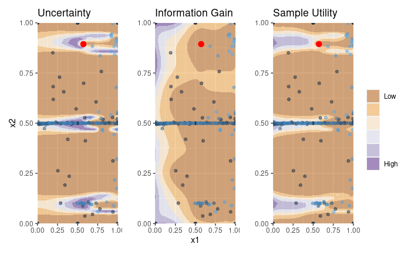

```r
(g1 + guides(fill = FALSE)) + (g2 + guides(fill = FALSE)) + g3
```

```r
## x3 slices
lower = c(0, 0.3, 0); upper = c(1, 0.7, 1)
fine.grid = expand.grid(x1 = seq(from = lower[1], to = upper[1], length.out = 50),
                        x2 = c(GPar.new$x2),
                        # x3 = c(0, 0.01, 0.1, 0.5, 1))
                        x3 = c(seq(from = lower[3], to = upper[3], length.out = 50)))
fine.grid = fine.grid[,1:3]
names(fine.grid) = c('x1', 'x2', 'x3')
# Apply Kriging function of distance
res = predict(object = mod.f1, newdata = fine.grid, type = "UK")
fine.grid$f1.mean = res$mean
fine.grid$f1.sd = res$sd

res = predict(object = mod.f2, newdata = data.frame(x1 = fine.grid$x1,
                     x2 = fine.grid$x2, x3 = fine.grid$x3), type = "UK")
fine.grid$f2.mean = res$mean
fine.grid$f2.sd = res$sd

# Probability that the distance is less than 1
fine.grid$prob = pnorm(q = 0, mean = fine.grid$f1.mean - 2, sd = fine.grid$f1.sd) *
  pnorm(q = 0, mean = fine.grid$f2.mean - 2, sd = fine.grid$f2.sd)
fine.grid$uncert = fine.grid$prob*(1-fine.grid$prob)+1e-10

# Information gain = variance = (var1*mean2)^2 + (var2*mean1)^2
fine.grid$info = (fine.grid$f1.sd/max(fine.grid$f1.sd))^2 + (fine.grid$f2.sd/max(fine.grid$f2.sd))^2

g1 = ggplot(fine.grid) +
  geom_contour_filled(mapping = aes(x = x1, y = x3, color = uncert, z = uncert),
                      breaks = seq(from = 0, to = 0.25, length.out = ncolor), alpha = 0.5) +
  geom_point(data = GPar.all, mapping = aes(x = x1, y = x3, color = order), size = 1.5, alpha = 0.5) +
  geom_point(data = GPar.new, mapping = aes(x = x1, y = x3), color = 'red', size = 3) +
  guides(color = FALSE) +
  scale_x_continuous(expand = c(0, 0)) + scale_y_continuous(expand = c(0, 0)) +
  scale_fill_brewer(labels = c("Low", rep("", ncolor-3), "High"), palette = "PuOr")  +
  labs(x = '', y = 'x3', title = 'Uncertainty')
```

```
`guides(<scale> = FALSE)` is deprecated. Please use `guides(<scale> = "none")` instead.
```

```r
rng = range(fine.grid$info)
g2 = ggplot(fine.grid) +
  geom_contour_filled(mapping = aes(x = x1, y = x3, color = info, z = info),
                      breaks = seq(from = rng[1]*0.99, to = rng[2]*1.01, length.out = ncolor), alpha = 0.5) +
  geom_point(data = GPar.all, mapping = aes(x = x1, y = x3, color = order), size = 1.5, alpha = 0.5) +
  geom_point(data = GPar.new, mapping = aes(x = x1, y = x3), color = 'red', size = 3) +
  guides(color = FALSE) +
  scale_x_continuous(expand = c(0, 0)) + scale_y_continuous(expand = c(0, 0)) +
  scale_fill_brewer(labels = c("Low", rep("", ncolor-3), "High"), palette = "PuOr")  +
  labs(x = 'x1', y = '', title = 'Information Gain')
```

```
`guides(<scale> = FALSE)` is deprecated. Please use `guides(<scale> = "none")` instead.
```

```r
rng = range(fine.grid$info*fine.grid$uncert)
g3 = ggplot(fine.grid) +
  geom_contour_filled(mapping = aes(x = x1, y = x3, color = uncert*info, z = uncert*info),
                      breaks = seq(from = rng[1]*0.99, to = rng[2]*1.01, length.out = ncolor), alpha = 0.5) +
  geom_point(data = GPar.all, mapping = aes(x = x1, y = x3, color = order), size = 1.5, alpha = 0.5) +
  geom_point(data = GPar.new, mapping = aes(x = x1, y = x3), color = 'red', size = 3) +
  guides(color = FALSE) +
  scale_x_continuous(expand = c(0, 0)) + scale_y_continuous(expand = c(0, 0)) +
  scale_fill_brewer(labels = c("Low", rep("", ncolor-3), "High"), palette = "PuOr", name = '')  +
  labs(x = '', y = '', title = 'Sample Utility')
```

```
`guides(<scale> = FALSE)` is deprecated. Please use `guides(<scale> = "none")` instead.
```

```
`guides(<scale> = FALSE)` is deprecated. Please use `guides(<scale> = "none")` instead.`guides(<scale> = FALSE)` is deprecated. Please use `guides(<scale> = "none")` instead.
```

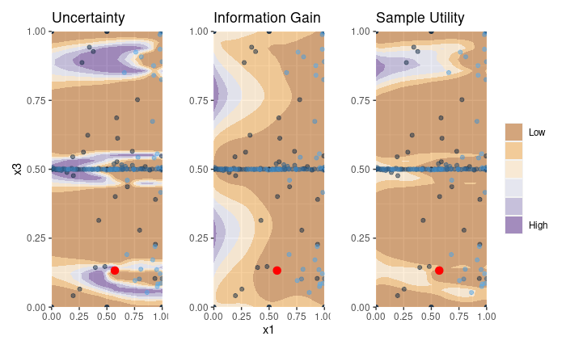

```r
(g1 + guides(fill = FALSE)) + (g2 + guides(fill = FALSE)) + g3
```

```r
rm(g1, g2, g3, fine.grid)
```

As indicated by this acceptance criteria, the boundary of the set it well defined with just the Pareto frontier, so additional iterations are not as necessary. Continuing with the procedure to show the feature importance and acceptance probability procedures.

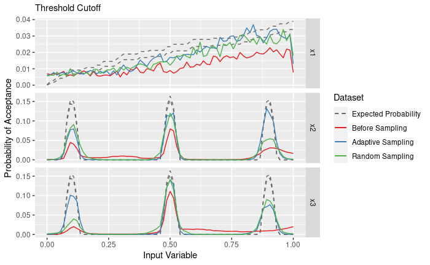

```r
# Load data: compare before/after refinement and with a random sampling for the refinement
GPar.start = read.csv(file = 'GPar_all_start.csv')
GPar.adapt = read.csv(file = 'GPar_Accept_Threshold.csv')
GPar.front = read.csv(file = 'GPar_fnt_start.csv')

# Compare to a random sample set
nsamp = nrow(GPar.adapt) - nrow(GPar.start)
GPar.rando = data.frame(x1 = runif(n = nsamp, min = 0, max = 1),
                        x2 = runif(n = nsamp, min = 0, max = 1),
                        x3 = runif(n = nsamp, min = 0, max = 1))
res = ZDT4.mod(x = as.matrix(GPar.rando))
GPar.rando$f1 = res[,1]; GPar.rando$f2 = res[,2]
# Fill in the remaining calculations: normalized outputs, distance, theta, order
GPar.rando = n.obj(GPar.data = GPar.rando, GPar.front = GPar.front)
cl <- makeCluster(2)
registerDoParallel(cl)
dist = foreach(row = 1:nrow(GPar.rando)) %dopar%
  n.dist(f1.norm = GPar.rando$f1.norm[row], f2.norm = GPar.rando$f2.norm[row], GPar.front = GPar.front)
stopCluster(cl)
GPar.rando$dist = unlist(dist)
GPar.rando$theta = atan(GPar.rando$f2.norm/GPar.rando$f1.norm)*180/pi*10/9
GPar.rando$order = seq(from = max(GPar.start$order) + 1, to = max(GPar.start$order) + nsamp, by = 1)
GPar.rando = rbind(GPar.start[, names(GPar.start) %in% names(GPar.rando)], GPar.rando)

# Use the final GP model with the full dataset
mod.f1.start = fill.sample.mod(GPar.data = GPar.start, input.name = c('x1', 'x2', 'x3'), output.name = 'f1.norm')
mod.f2.start = fill.sample.mod(GPar.data = GPar.start, input.name = c('x1', 'x2', 'x3'), output.name = 'f2.norm')

mod.f1.adapt = fill.sample.mod(GPar.data = GPar.adapt, input.name = c('x1', 'x2', 'x3'), output.name = 'f1.norm')
mod.f2.adapt = fill.sample.mod(GPar.data = GPar.adapt, input.name = c('x1', 'x2', 'x3'), output.name = 'f2.norm')

mod.f1.rando = fill.sample.mod(GPar.data = GPar.rando, input.name = c('x1', 'x2', 'x3'), output.name = 'f1.norm')
mod.f2.rando = fill.sample.mod(GPar.data = GPar.rando, input.name = c('x1', 'x2', 'x3'), output.name = 'f2.norm')

# Obtain marginalized probabilities with a fine resolution grid (50 points). Calculate the integral with a Monte Carlo sampling of 1500 samples each.
Infer.cut.start = marginal.cut(mod.f1.start, mod.f2.start)
Infer.cut.adapt = marginal.cut(mod.f1.adapt, mod.f2.adapt)
Infer.cut.rando = marginal.cut(mod.f1.rando, mod.f2.rando)

# Compare to true marginal
cutof.tru = read.csv('ExpectedMarginal_cutof.csv')

ggplot() +
  geom_path(data = cutof.tru,        mapping = aes(x = x, y = prob+psd, color = 'tru'), linetype = 2) +
  geom_path(data = cutof.tru,        mapping = aes(x = x, y = prob-psd, color = 'tru'), linetype = 2) +
  geom_path(data = Infer.cut.start, mapping = aes(x = x, y = prob, color = 'start')) +
  geom_path(data = Infer.cut.adapt, mapping = aes(x = x, y = prob, color = 'adapt')) +
  geom_path(data = Infer.cut.rando, mapping = aes(x = x, y = prob, color = 'rando')) +
  facet_grid(var~., scales = 'free_y') +
  labs(x = 'Input Variable', y = 'Probability of Acceptance', subtitle = 'Threshold Cutoff',
       color = 'Dataset') +
  scale_color_manual(labels = c('tru' = 'Expected Probability',
                                  'start' = 'Before Sampling',
                                  'adapt' = 'Adaptive Sampling', 'rando' = 'Random Sampling'),
                       values = c('tru' = 'grey40', 'start' = '#e41a1c', 'adapt' = '#377eb8', 'rando' = '#4daf4a'),
                       breaks = c('tru', 'start', 'adapt', 'rando')) +
  guides(color = guide_legend(override.aes = list(linetype = c(2, 1, 1, 1))))
```

```r
# Coefficients of determination.
expect1 = filter(cutof.tru, var == 'x1')$prob
expect2 = filter(cutof.tru, var == 'x2')$prob
expect3 = filter(cutof.tru, var == 'x3')$prob
data.frame(method = c('Before Sampling', 'Adaptive Sampling', 'Random Sampling'),
           R2.x1 = c(cor(x = filter(Infer.cut.start, var == 'x1')$prob, y = expect1, method = 'pearson')^2,
             cor(x = filter(Infer.cut.adapt, var == 'x1')$prob, y = expect1, method = 'pearson')^2,
             cor(x = filter(Infer.cut.rando, var == 'x1')$prob, y = expect1, method = 'pearson')^2),
           R2.x2 = c(cor(x = filter(Infer.cut.start, var == 'x2')$prob, y = expect2, method = 'pearson')^2,
             cor(x = filter(Infer.cut.adapt, var == 'x2')$prob, y = expect2, method = 'pearson')^2,
             cor(x = filter(Infer.cut.rando, var == 'x2')$prob, y = expect2, method = 'pearson')^2),
           R2.x3 = c(cor(x = filter(Infer.cut.start, var == 'x3')$prob, y = expect3, method = 'pearson')^2,
             cor(x = filter(Infer.cut.adapt, var == 'x3')$prob, y = expect3, method = 'pearson')^2,
             cor(x = filter(Infer.cut.rando, var == 'x3')$prob, y = expect3, method = 'pearson')^2)
           )
```

| method | R2.x1 | R2.x2 | R2.x3 |
| --- | --- | --- | --- |
| Before Sampling | 0.6843160 | 0.7067096 | 0.3734510 |
| Adaptive Sampling | 0.7867582 | 0.9086792 | 0.9049842 |
| Random Sampling | 0.8240988 | 0.8501586 | 0.7364504 |

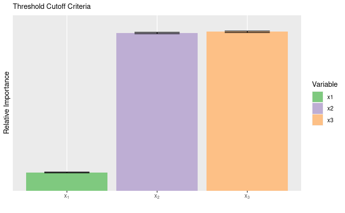

```r
# Relative importance: inverse of the area under the curve, normalized units,
# adjusted by the range of the probabilities' means
Infer.x1 = filter(Infer.cut.adapt, var == 'x1')
Infer.x2 = filter(Infer.cut.adapt, var == 'x2')
Infer.x3 = filter(Infer.cut.adapt, var == 'x3')
Import.cutof = data.frame(import = c(diff(range(Infer.x1$prob))*nrow(Infer.x1)/sum(Infer.x1$psd),
                                     diff(range(Infer.x2$prob))*nrow(Infer.x2)/sum(Infer.x2$psd),
                                     diff(range(Infer.x3$prob))*nrow(Infer.x3)/sum(Infer.x3$psd)),
                          var = c('x1', 'x2', 'x3'),
                          typ = 'cutof')
# Uncertainty in the calculation based on the Monte Carlo error
Import.cutof$sd = sqrt(c(max(Infer.x1$prob)*(1-max(Infer.x1$prob)) + min(Infer.x1$prob)*(1-min(Infer.x1$prob)) *
                      diff(range(Infer.x1$prob)),
                    max(Infer.x2$prob)*(1-max(Infer.x2$prob)) + min(Infer.x2$prob)*(1-min(Infer.x2$prob)) *
                      diff(range(Infer.x2$prob)),
                    max(Infer.x3$prob)*(1-max(Infer.x3$prob)) + min(Infer.x3$prob)*(1-min(Infer.x3$prob)) *
                      diff(range(Infer.x3$prob)) )/1500 +
                  c(var(Infer.x1$psd), var(Infer.x2$psd), var(Infer.x3$psd))/nrow(Infer.x1) )

ggplot(Import.cutof) +
  geom_col(mapping = aes(x = var, y = import, fill = var)) +
  geom_errorbar(mapping = aes(x = var, ymin = import - sd, ymax = import + sd), width = 0.5) +
  labs(x = '', y = 'Relative Importance', fill = 'Variable',
       subtitle = expression('Threshold Cutoff Criteria')) +
  scale_y_continuous(breaks = c(), expand = expansion(mult = c(0, .1))) +
  scale_x_discrete(labels = c(expression('x'[1]), expression('x'[2]), expression('x'[3]))) +
  scale_fill_manual(values = c('#7fc97f', '#beaed4', '#fdc086'))
```

```r
# Store the data for importance ranking comparison later
Infer.plt = rbind(Infer.x1, Infer.x2, Infer.x3);
cutof.tru$cat = 'tru';          Infer.cut.start$cat = 'start'
Infer.cut.adapt$cat = 'adapt'; Infer.cut.rando$cat = 'rando'
write.csv(rbind(cutof.tru[, names(cutof.tru) %in% names(Infer.cut.start)],
      Infer.cut.start[, names(Infer.cut.start) %in% names(cutof.tru)],
      Infer.cut.adapt[, names(Infer.cut.adapt) %in% names(cutof.tru)],
      Infer.cut.rando[, names(Infer.cut.rando) %in% names(cutof.tru)]), 'Marginals_cutof_tru.csv')
```

### Utopia Distance and Prioritization

Since the utopia point is set to (0,0), the distance to the utopia point is simple to calculate from the normalized coordinates. Acceptable points are those that prioritize the first objective by at least 80%, which can be determined by the angle theta.

Load the original dataset.

```r
# Load data
GPar.all = read.csv(file = 'GPar_all_start.csv')
GPar.front = read.csv(file = 'GPar_fnt_start.csv')

# Remove leading indices: the names are:
while(names(GPar.all)[1] != 'x1'){
  GPar.all = GPar.all[,2:length(names(GPar.all))]
}
while(names(GPar.front)[1] != 'x1'){
  GPar.front = GPar.front[,2:length(names(GPar.front))]
}
```

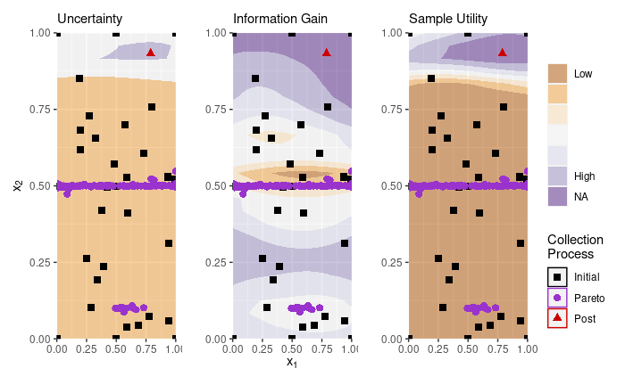

```r
# Search for the first point
GPar.all$rad = sqrt(GPar.all$f1.norm^2 + GPar.all$f2.norm^2)
mod.rad = fill.sample.mod(GPar.data = GPar.all, input.name = c('x1', 'x2', 'x3'), output.name = 'rad')
mod.ang = fill.sample.mod(GPar.data = GPar.all, input.name = c('x1', 'x2', 'x3'), output.name = 'theta')
GA.pred = ga(type = 'real-valued',
             fitness = function(x){fill.sample.radan(x, model.f1 = mod.rad, model.f2 = mod.ang)},
             lower = c(0, 0, 0), upper = c(1, 1, 1),
             popSize = 100, maxiter = 100, run = 10, monitor = FALSE,
             parallel = 2)
# Next point to sample is the solution to this optimization
point.next = GA.pred@solution[1,]

# Account for the possibility that the genetic algorithm converges on multiple equivalent points
GPar.new = data.frame(x1 = point.next[1], x2 = point.next[2], x3 = point.next[3])
res = ZDT4.mod(x = as.matrix(GPar.new))
GPar.new$f1 = res[,1]; GPar.new$f2 = res[,2]
# Add point to the samples
res = fill.sample.update(GPar.front.old = GPar.front, GPar.data = GPar.all, GPar.new = GPar.new)
GPar.front = res$front
GPar.all = res$data
rm(res)
GPar.all$rad = sqrt(GPar.all$f1.norm^2 + GPar.all$f2.norm^2)

# The cutoff point for the loop is 20 additional points or when the fitness value is less than half of this starting fitness value
start.fit = max(GA.pred@fitness)
# Store first point for plotting
GPar.new1 = GPar.new
rm(dist)

# Store the initial mod.dist for later
mod.rad.init = mod.rad
mod.ang.init = mod.ang

# Grid of the relevant region to visualize
lower = c(0, 0, 0); upper = c(1, 1, 1)
fine.grid = expand.grid(x1 = seq(from = lower[1], to = upper[1], length.out = 50),
                        x2 = c(GPar.new$x2, seq(from = lower[2], to = upper[2], length.out = 25)),
                        # x3 = c(0, 0.01, 0.1, 0.5, 1))
                        x3 = c(GPar.new$x3, seq(from = lower[3], to = upper[3], length.out = 25)))
fine.grid = fine.grid[,1:3]
names(fine.grid) = c('x1', 'x2', 'x3')

# Apply Kriging functions
res = predict(object = mod.rad.init, newdata = fine.grid, type = "UK")
fine.grid$rad.mean = res$mean
fine.grid$rad.sd = res$sd

res = predict(object = mod.ang.init, newdata = data.frame(x1 = fine.grid$x1,
                      x2 = fine.grid$x2, x3 = fine.grid$x3), type = "UK")
fine.grid$ang.mean = res$mean
fine.grid$ang.sd = res$sd

# Uncertainty = P(success)*(1 - P(success))
fine.grid$prob = pnorm(q = 0, mean = fine.grid$rad.mean - 2, sd = fine.grid$rad.sd) *
  (1 - pnorm(q = 0, mean = fine.grid$ang.mean - 20, sd = fine.grid$ang.sd))

# Information gain = variance = (var1*mean2)^2 + (var2*mean1)^2
fine.grid$info = (fine.grid$rad.sd/max(fine.grid$rad.sd))^2 + (fine.grid$ang.sd/max(fine.grid$ang.sd))^2

ncolor = 7; pt.size = 2.5
g1 = ggplot() +
  geom_contour_filled(data = filter(fine.grid, x3 == GPar.new$x3, x2 != GPar.new$x2),
                      mapping = aes(x = x1, y = x2, z = (prob)*(1-prob)-1e-10,
                                    color = (prob)*(1-prob)-1e-10), alpha = 0.5,
                      breaks = seq(from = -0.01, to = 0.25, length.out = ncolor)
                      )+
  geom_contour(data = filter(fine.grid, x3 == GPar.new$x3, x2 != GPar.new$x2),
               mapping = aes(x = x1, y = x2, z = prob), breaks = c(0.25, 0.75), color = 'blue') +
  geom_point(data = filter(GPar.all, x1 <= upper[1], x1 >= lower[1], x2 <= upper[2], x2 >= lower[2], order == 0),
             mapping = aes(x = x1, y = x2, color = 'initial', shape = 'initial'), size = pt.size) +
  geom_point(data = filter(GPar.all, x1 <= upper[1], x1 >= lower[1], x2 <= upper[2], x2 >= lower[2],
                           order > 0, order < Pareto.budget+1),
             mapping = aes(x = x1, y = x2, color = 'Pareto', shape = 'Pareto'), size = pt.size) +
  geom_point(data = GPar.new1, mapping = aes(x = x1, y = x2, color = 'Post', shape = 'Post'), size = pt.size) +
  scale_fill_brewer(palette = "PuOr") +
  scale_color_manual(values = c('initial' = 'black', 'Pareto' = 'darkorchid3', 'Post' = 'red3'),
                     labels = c('Initial', 'Pareto', 'Post'), breaks = c('initial', 'Pareto', 'Post')) +
  scale_shape_manual(values = c('initial' = 15, 'Pareto' = 16, 'Post' = 17),
                     labels = c('Initial', 'Pareto', 'Post'), breaks = c('initial', 'Pareto', 'Post')) +
  scale_x_continuous(expand = c(0, 0)) + scale_y_continuous(expand = c(0, 0)) +
  labs(x = "", y = expression("x"[2]), subtitle = 'Uncertainty') +  guides(fill = FALSE, color = FALSE, shape = FALSE)

g2 = ggplot() +
  geom_contour_filled(data = filter(fine.grid, x3 == GPar.new$x3, x2 != GPar.new$x2),
                      mapping = aes(x = x1, y = x2, z = info, color = info), bins = ncolor, alpha = 0.5)+
  geom_point(data = filter(GPar.all, x1 <= upper[1], x1 >= lower[1], x2 <= upper[2], x2 >= lower[2], order == 0),
             mapping = aes(x = x1, y = x2, color = 'initial', shape = 'initial'), size = pt.size) +
  geom_point(data = filter(GPar.all, x1 <= upper[1], x1 >= lower[1], x2 <= upper[2], x2 >= lower[2],
                           order > 0, order < Pareto.budget+1),
             mapping = aes(x = x1, y = x2, color = 'Pareto', shape = 'Pareto'), size = pt.size) +
  geom_point(data = GPar.new1, mapping = aes(x = x1, y = x2, color = 'Post', shape = 'Post'), size = pt.size) +
  scale_fill_brewer(palette = "PuOr") +
  scale_color_manual(values = c('initial' = 'black', 'Pareto' = 'darkorchid3', 'Post' = 'red3'),
                     labels = c('Initial', 'Pareto', 'Post'), breaks = c('initial', 'Pareto', 'Post')) +
  scale_shape_manual(values = c('initial' = 15, 'Pareto' = 16, 'Post' = 17),
                     labels = c('Initial', 'Pareto', 'Post'), breaks = c('initial', 'Pareto', 'Post')) +
  scale_x_continuous(expand = c(0, 0)) + scale_y_continuous(expand = c(0, 0)) +
  labs(x = expression("x"[1]), y = "", subtitle = 'Information Gain') +  guides(fill = FALSE, color = FALSE, shape = FALSE)

g3 = ggplot() +
  geom_contour_filled(data = filter(fine.grid, x3 == GPar.new$x3, x2 != GPar.new$x2),
                      mapping = aes(x = x1, y = x2, z = info*(prob)*(1-prob), color = info*(prob)*(1-info)),
                      bins = ncolor, alpha = 0.5)+
  geom_point(data = filter(GPar.all, x1 <= upper[1], x1 >= lower[1], x2 <= upper[2], x2 >= lower[2], order == 0),
             mapping = aes(x = x1, y = x2, color = 'initial', shape = 'initial'), size = pt.size) +
  geom_point(data = filter(GPar.all, x1 <= upper[1], x1 >= lower[1], x2 <= upper[2], x2 >= lower[2],
                           order > 0, order < Pareto.budget+1),
             mapping = aes(x = x1, y = x2, color = 'Pareto', shape = 'Pareto'), size = pt.size) +
  geom_point(data = GPar.new1, mapping = aes(x = x1, y = x2, color = 'Post', shape = 'Post'), size = pt.size) +
  scale_fill_brewer(labels = c("Low", rep("", ncolor-3), "High"), palette = "PuOr")  +
  scale_color_manual(values = c('initial' = 'black', 'Pareto' = 'darkorchid3', 'Post' = 'red3'),
                     labels = c('Initial', 'Pareto', 'Post'), breaks = c('initial', 'Pareto', 'Post')) +
  scale_shape_manual(values = c('initial' = 15, 'Pareto' = 16, 'Post' = 17),
                     labels = c('Initial', 'Pareto', 'Post'), breaks = c('initial', 'Pareto', 'Post')) +
  labs(x = "", y = "", subtitle = "Sample Utility", fill = "", shape = 'Collection\nProcess', color = 'Collection\nProcess') +
  scale_x_continuous(expand = c(0, 0)) + scale_y_continuous(expand = c(0, 0)) +
  guides(color=guide_legend(override.aes=list(fill=NA))) # Remove fill in the legend

g1 + g2 + g3
```

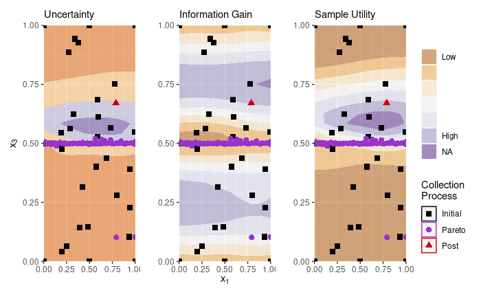

```r
g1 = ggplot() +
  geom_contour_filled(data = filter(fine.grid, x2 == GPar.new$x2, x3 != GPar.new$x3),
                      mapping = aes(x = x1, y = x3, z = (prob)*(1-prob)-1e-10,
                                    color = (prob)*(1-prob)-1e-10), alpha = 0.5,
                      breaks = seq(from = -0.01, to = 0.25, length.out = ncolor)
                      )+
  geom_contour(data = filter(fine.grid, x2 == GPar.new$x2, x3 != GPar.new$x3),
               mapping = aes(x = x1, y = x3, z = prob), breaks = c(0.25, 0.75), color = 'blue') +
  geom_point(data = filter(GPar.all, x1 <= upper[1], x1 >= lower[1], x2 <= upper[2], x2 >= lower[2], order == 0),
             mapping = aes(x = x1, y = x3, color = 'initial', shape = 'initial'), size = pt.size) +
  geom_point(data = filter(GPar.all, x1 <= upper[1], x1 >= lower[1], x2 <= upper[2], x2 >= lower[2],
                           order > 0, order < Pareto.budget+1),
             mapping = aes(x = x1, y = x3, color = 'Pareto', shape = 'Pareto'), size = pt.size) +
  geom_point(data = GPar.new1, mapping = aes(x = x1, y = x3, color = 'Post', shape = 'Post'), size = pt.size) +
  scale_fill_brewer(palette = "PuOr") +
  scale_color_manual(values = c('initial' = 'black', 'Pareto' = 'darkorchid3', 'Post' = 'red3'),
                     labels = c('Initial', 'Pareto', 'Post'), breaks = c('initial', 'Pareto', 'Post')) +
  scale_shape_manual(values = c('initial' = 15, 'Pareto' = 16, 'Post' = 17),
                     labels = c('Initial', 'Pareto', 'Post'), breaks = c('initial', 'Pareto', 'Post')) +
  scale_x_continuous(expand = c(0, 0)) + scale_y_continuous(expand = c(0, 0)) +
  labs(x = "", y = expression("x"[3]), subtitle = 'Uncertainty') +  guides(fill = FALSE, color = FALSE, shape = FALSE)

g2 = ggplot() +
  geom_contour_filled(data = filter(fine.grid, x2 == GPar.new$x2, x3 != GPar.new$x3),
                      mapping = aes(x = x1, y = x3, z = info, color = info), bins = ncolor, alpha = 0.5)+
  geom_point(data = filter(GPar.all, x1 <= upper[1], x1 >= lower[1], x2 <= upper[2], x2 >= lower[2], order == 0),
             mapping = aes(x = x1, y = x3, color = 'initial', shape = 'initial'), size = pt.size) +
  geom_point(data = filter(GPar.all, x1 <= upper[1], x1 >= lower[1], x2 <= upper[2], x2 >= lower[2],
                           order > 0, order < Pareto.budget+1),
             mapping = aes(x = x1, y = x3, color = 'Pareto', shape = 'Pareto'), size = pt.size) +
  geom_point(data = GPar.new1, mapping = aes(x = x1, y = x3, color = 'Post', shape = 'Post'), size = pt.size) +
  scale_fill_brewer(palette = "PuOr") +
  scale_color_manual(values = c('initial' = 'black', 'Pareto' = 'darkorchid3', 'Post' = 'red3'),
                     labels = c('Initial', 'Pareto', 'Post'), breaks = c('initial', 'Pareto', 'Post')) +
  scale_shape_manual(values = c('initial' = 15, 'Pareto' = 16, 'Post' = 17),
                     labels = c('Initial', 'Pareto', 'Post'), breaks = c('initial', 'Pareto', 'Post')) +
  scale_x_continuous(expand = c(0, 0)) + scale_y_continuous(expand = c(0, 0)) +
  labs(x = expression("x"[1]), y = "", subtitle = 'Information Gain') +  guides(fill = FALSE, color = FALSE, shape = FALSE)

g3 = ggplot() +
  geom_contour_filled(data = filter(fine.grid, x2 == GPar.new$x2, x3 != GPar.new$x3),
                      mapping = aes(x = x1, y = x3, z = info*(prob)*(1-prob), color = info*(prob)*(1-prob)),
                      bins = ncolor, alpha = 0.5)+
  geom_point(data = filter(GPar.all, x1 <= upper[1], x1 >= lower[1], x2 <= upper[2], x2 >= lower[2], order == 0),
             mapping = aes(x = x1, y = x3, color = 'initial', shape = 'initial'), size = pt.size) +
  geom_point(data = filter(GPar.all, x1 <= upper[1], x1 >= lower[1], x2 <= upper[2], x2 >= lower[2],
                           order > 0, order < Pareto.budget+1),
             mapping = aes(x = x1, y = x3, color = 'Pareto', shape = 'Pareto'), size = pt.size) +
  geom_point(data = GPar.new1, mapping = aes(x = x1, y = x3, color = 'Post', shape = 'Post'), size = pt.size) +
  scale_fill_brewer(labels = c("Low", rep("", ncolor-3), "High"), palette = "PuOr")  +
  scale_color_manual(values = c('initial' = 'black', 'Pareto' = 'darkorchid3', 'Post' = 'red3'),
                     labels = c('Initial', 'Pareto', 'Post'), breaks = c('initial', 'Pareto', 'Post')) +
  scale_shape_manual(values = c('initial' = 15, 'Pareto' = 16, 'Post' = 17),
                     labels = c('Initial', 'Pareto', 'Post'), breaks = c('initial', 'Pareto', 'Post')) +
  labs(x = "", y = "", subtitle = "Sample Utility", fill = "",
       shape = 'Collection\nProcess', color = 'Collection\nProcess') +
  scale_x_continuous(expand = c(0, 0)) + scale_y_continuous(expand = c(0, 0)) +
  guides(color=guide_legend(override.aes=list(fill=NA))) # Remove fill in the legend

g1 + g2 + g3
```

```r
# Sometimes the grid scan finds a point that is slightly better than the perceived optimum due to the convergence criteria. In that event, replace the starting point for the cutoff criteria for iteration
start.fit = max(start.fit, max(fine.grid$inf*fine.grid$prob*(1-fine.grid$prob)))

rm(g1, g2, g3, fine.grid)
```

```r
budget = 30
next.fit = start.fit
while(next.fit > start.fit*0.005 & max(GPar.all$order) < budget+Pareto.budget){
  # Create a Kriging model for the distance
  mod.rad = fill.sample.mod(GPar.data = GPar.all, input.name = c('x1', 'x2', 'x3'), output.name = 'rad')
  mod.ang = fill.sample.mod(GPar.data = GPar.all, input.name = c('x1', 'x2', 'x3'), output.name = 'theta')
  GA.pred = ga(type = 'real-valued',
               fitness = function(x){fill.sample.radan(x, model.f1 = mod.rad, model.f2 = mod.ang)},
               lower = c(0, 0, 0), upper = c(1, 1, 1),
               popSize = 100, maxiter = 100, run = 10, monitor = FALSE,
               parallel = 2)

  # Next point to sample is the solution to this optimization.
  # Account for the possibility that the genetic algorithm converges on multiple equivalent points
  point.next = GA.pred@solution[1,]

  # Find values of the selected point
  GPar.new = data.frame(x1 = point.next[1], x2 = point.next[2], x3 = point.next[3])
  res = ZDT4.mod(x = as.matrix(GPar.new))
  GPar.new$f1 = res[,1]; GPar.new$f2 = res[,2]

  # Add point to the samples
  res = fill.sample.update(GPar.front.old = GPar.front, GPar.data = GPar.all, GPar.new = GPar.new)
  GPar.front = res$front
  GPar.all = res$data
  rm(res)
  GPar.all$rad = sqrt(GPar.all$f1.norm^2 + GPar.all$f2.norm^2)

  # The cutoff point for the loop is 20 additional points or when the fitness value is less than half of this starting fitness value
  next.fit = max(GA.pred@fitness)
}

write.csv(GPar.all, 'GPar_Accept_Radius.csv')

rm(res, cl, point.next)
```

```r
GPar.all = read.csv(file = 'GPar_Accept_Radius.csv')
# Plot results on top of the most recent Kriging model
mod.rad = fill.sample.mod(GPar.data = GPar.all, input.name = c('x1', 'x2', 'x3'), output.name = 'rad')
mod.ang = fill.sample.mod(GPar.data = GPar.all, input.name = c('x1', 'x2', 'x3'), output.name = 'theta')

# Grid of the relevant region to visualize
lower = c(0, 0, 0); upper = c(1, 1, 1)
fine.grid = expand.grid(x1 = seq(from = lower[1], to = upper[1], length.out = 50),
                        x2 = c(GPar.new$x2, seq(from = lower[2], to = upper[2], length.out = 25)),
                        # x3 = c(0, 0.01, 0.1, 0.5, 1))
                        x3 = c(GPar.new$x3, seq(from = lower[3], to = upper[3], length.out = 25)))
fine.grid = fine.grid[,1:3]
names(fine.grid) = c('x1', 'x2', 'x3')

# Apply Kriging functions
res = predict(object = mod.rad, newdata = fine.grid, type = "UK")
fine.grid$rad.mean = res$mean
fine.grid$rad.sd = res$sd

res = predict(object = mod.ang, newdata = data.frame(x1 = fine.grid$x1,
                      x2 = fine.grid$x2, x3 = fine.grid$x3), type = "UK")
fine.grid$ang.mean = res$mean
fine.grid$ang.sd = res$sd

# Uncertainty = P(success)*(1 - P(success))
fine.grid$prob = pnorm(q = 0, mean = fine.grid$rad.mean - 2, sd = fine.grid$rad.sd) *
  (1 - pnorm(q = 0, mean = fine.grid$ang.mean - 20, sd = fine.grid$ang.sd))

# Information gain = variance = (var1*mean2)^2 + (var2*mean1)^2
fine.grid$info = (fine.grid$rad.sd/max(fine.grid$rad.sd))^2 + (fine.grid$ang.sd/max(fine.grid$ang.sd))^2

ncolor = 7; pt.size = 2.5
g1 = ggplot() +
  geom_contour_filled(data = filter(fine.grid, x3 == GPar.new$x3, x2 != GPar.new$x2),
                      mapping = aes(x = x1, y = x2, z = (prob)*(1-prob)-1e-10,
                                    color = (prob)*(1-prob)-1e-10), alpha = 0.5,
                      breaks = seq(from = -0.01, to = 0.25, length.out = ncolor)
                      )+
  geom_contour(data = filter(fine.grid, x3 == GPar.new$x3, x2 != GPar.new$x2),
               mapping = aes(x = x1, y = x2, z = prob), breaks = c(0.25, 0.75), color = 'blue') +
  geom_point(data = filter(GPar.all, x1 <= upper[1], x1 >= lower[1], x2 <= upper[2], x2 >= lower[2], order == 0),
             mapping = aes(x = x1, y = x2, color = 'initial', shape = 'initial'), size = pt.size) +
  geom_point(data = filter(GPar.all, x1 <= upper[1], x1 >= lower[1], x2 <= upper[2], x2 >= lower[2],
                           order > 0, order < Pareto.budget+1),
             mapping = aes(x = x1, y = x2, color = 'Pareto', shape = 'Pareto'), size = pt.size) +
  geom_point(data = filter(GPar.all, order > Pareto.budget),
             mapping = aes(x = x1, y = x2, color = 'Post', shape = 'Post'), size = pt.size) +
  scale_fill_brewer(palette = "PuOr") +
  scale_color_manual(values = c('initial' = 'black', 'Pareto' = 'darkorchid3', 'Post' = 'red3'),
                     labels = c('Initial', 'Pareto', 'Post'), breaks = c('initial', 'Pareto', 'Post')) +
  scale_shape_manual(values = c('initial' = 15, 'Pareto' = 16, 'Post' = 17),
                     labels = c('Initial', 'Pareto', 'Post'), breaks = c('initial', 'Pareto', 'Post')) +
  scale_x_continuous(expand = c(0, 0)) + scale_y_continuous(expand = c(0, 0)) +
  labs(x = "", y = expression("x"[2]), subtitle = 'Uncertainty') +  guides(fill = FALSE, color = FALSE, shape = FALSE)
```

```
`guides(<scale> = FALSE)` is deprecated. Please use `guides(<scale> = "none")` instead.
```

```r
g2 = ggplot() +
  geom_contour_filled(data = filter(fine.grid, x3 == GPar.new$x3, x2 != GPar.new$x2),
                      mapping = aes(x = x1, y = x2, z = info, color = info), bins = ncolor, alpha = 0.5)+
  geom_point(data = filter(GPar.all, x1 <= upper[1], x1 >= lower[1], x2 <= upper[2], x2 >= lower[2], order == 0),
             mapping = aes(x = x1, y = x2, color = 'initial', shape = 'initial'), size = pt.size) +
  geom_point(data = filter(GPar.all, x1 <= upper[1], x1 >= lower[1], x2 <= upper[2], x2 >= lower[2],
                           order > 0, order < Pareto.budget+1),
             mapping = aes(x = x1, y = x2, color = 'Pareto', shape = 'Pareto'), size = pt.size) +
  geom_point(data = filter(GPar.all, order > Pareto.budget),
             mapping = aes(x = x1, y = x2, color = 'Post', shape = 'Post'), size = pt.size) +
  scale_fill_brewer(palette = "PuOr") +
  scale_color_manual(values = c('initial' = 'black', 'Pareto' = 'darkorchid3', 'Post' = 'red3'),
                     labels = c('Initial', 'Pareto', 'Post'), breaks = c('initial', 'Pareto', 'Post')) +
  scale_shape_manual(values = c('initial' = 15, 'Pareto' = 16, 'Post' = 17),
                     labels = c('Initial', 'Pareto', 'Post'), breaks = c('initial', 'Pareto', 'Post')) +
  scale_x_continuous(expand = c(0, 0)) + scale_y_continuous(expand = c(0, 0)) +
  labs(x = expression("x"[1]), y = "", subtitle = 'Information Gain') +  guides(fill = FALSE, color = FALSE, shape = FALSE)
```

```
`guides(<scale> = FALSE)` is deprecated. Please use `guides(<scale> = "none")` instead.
```

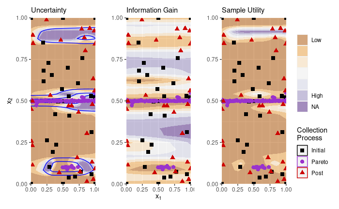

```r
g3 = ggplot() +
  geom_contour_filled(data = filter(fine.grid, x3 == GPar.new$x3, x2 != GPar.new$x2),
                      mapping = aes(x = x1, y = x2, z = info*(prob)*(1-prob), color = info*(prob)*(1-info)),
                      bins = ncolor, alpha = 0.5)+
  geom_point(data = filter(GPar.all, x1 <= upper[1], x1 >= lower[1], x2 <= upper[2], x2 >= lower[2], order == 0),
             mapping = aes(x = x1, y = x2, color = 'initial', shape = 'initial'), size = pt.size) +
  geom_point(data = filter(GPar.all, x1 <= upper[1], x1 >= lower[1], x2 <= upper[2], x2 >= lower[2],
                           order > 0, order < Pareto.budget+1),
             mapping = aes(x = x1, y = x2, color = 'Pareto', shape = 'Pareto'), size = pt.size) +
  geom_point(data = filter(GPar.all, order > Pareto.budget),
             mapping = aes(x = x1, y = x2, color = 'Post', shape = 'Post'), size = pt.size) +
  scale_fill_brewer(labels = c("Low", rep("", ncolor-3), "High"), palette = "PuOr")  +
  scale_color_manual(values = c('initial' = 'black', 'Pareto' = 'darkorchid3', 'Post' = 'red3'),
                     labels = c('Initial', 'Pareto', 'Post'), breaks = c('initial', 'Pareto', 'Post')) +
  scale_shape_manual(values = c('initial' = 15, 'Pareto' = 16, 'Post' = 17),
                     labels = c('Initial', 'Pareto', 'Post'), breaks = c('initial', 'Pareto', 'Post')) +
  labs(x = "", y = "", subtitle = "Sample Utility", fill = "", shape = 'Collection\nProcess', color = 'Collection\nProcess') +
  scale_x_continuous(expand = c(0, 0)) + scale_y_continuous(expand = c(0, 0)) +
  guides(color=guide_legend(override.aes=list(fill=NA))) # Remove fill in the legend

g1 + g2 + g3
```

```r
g1 = ggplot() +
  geom_contour_filled(data = filter(fine.grid, x2 == GPar.new$x2, x3 != GPar.new$x3),
                      mapping = aes(x = x1, y = x3, z = (prob)*(1-prob)-1e-10,
                                    color = (prob)*(1-prob)-1e-10), alpha = 0.5,
                      breaks = seq(from = -0.01, to = 0.25, length.out = ncolor)
                      )+
  geom_contour(data = filter(fine.grid, x2 == GPar.new$x2, x3 != GPar.new$x3),
               mapping = aes(x = x1, y = x3, z = prob), breaks = c(0.25, 0.75), color = 'blue') +
  geom_point(data = filter(GPar.all, x1 <= upper[1], x1 >= lower[1], x2 <= upper[2], x2 >= lower[2], order == 0),
             mapping = aes(x = x1, y = x3, color = 'initial', shape = 'initial'), size = pt.size) +
  geom_point(data = filter(GPar.all, x1 <= upper[1], x1 >= lower[1], x2 <= upper[2], x2 >= lower[2],
                           order > 0, order < Pareto.budget+1),
             mapping = aes(x = x1, y = x3, color = 'Pareto', shape = 'Pareto'), size = pt.size) +
  geom_point(data = filter(GPar.all, order > Pareto.budget),
             mapping = aes(x = x1, y = x3, color = 'Post', shape = 'Post'), size = pt.size) +
  scale_fill_brewer(palette = "PuOr") +
  scale_color_manual(values = c('initial' = 'black', 'Pareto' = 'darkorchid3', 'Post' = 'red3'),
                     labels = c('Initial', 'Pareto', 'Post'), breaks = c('initial', 'Pareto', 'Post')) +
  scale_shape_manual(values = c('initial' = 15, 'Pareto' = 16, 'Post' = 17),
                     labels = c('Initial', 'Pareto', 'Post'), breaks = c('initial', 'Pareto', 'Post')) +
  scale_x_continuous(expand = c(0, 0)) + scale_y_continuous(expand = c(0, 0)) +
  labs(x = "", y = expression("x"[3]), subtitle = 'Uncertainty') +  guides(fill = FALSE, color = FALSE, shape = FALSE)
```

```
`guides(<scale> = FALSE)` is deprecated. Please use `guides(<scale> = "none")` instead.
```

```r
g2 = ggplot() +
  geom_contour_filled(data = filter(fine.grid, x2 == GPar.new$x2, x3 != GPar.new$x3),
                      mapping = aes(x = x1, y = x3, z = info, color = info), bins = ncolor, alpha = 0.5)+
  geom_point(data = filter(GPar.all, x1 <= upper[1], x1 >= lower[1], x2 <= upper[2], x2 >= lower[2], order == 0),
             mapping = aes(x = x1, y = x3, color = 'initial', shape = 'initial'), size = pt.size) +
  geom_point(data = filter(GPar.all, x1 <= upper[1], x1 >= lower[1], x2 <= upper[2], x2 >= lower[2],
                           order > 0, order < Pareto.budget+1),
             mapping = aes(x = x1, y = x3, color = 'Pareto', shape = 'Pareto'), size = pt.size) +
  geom_point(data = filter(GPar.all, order > Pareto.budget),
             mapping = aes(x = x1, y = x3, color = 'Post', shape = 'Post'), size = pt.size) +
  scale_fill_brewer(palette = "PuOr") +
  scale_color_manual(values = c('initial' = 'black', 'Pareto' = 'darkorchid3', 'Post' = 'red3'),
                     labels = c('Initial', 'Pareto', 'Post'), breaks = c('initial', 'Pareto', 'Post')) +
  scale_shape_manual(values = c('initial' = 15, 'Pareto' = 16, 'Post' = 17),
                     labels = c('Initial', 'Pareto', 'Post'), breaks = c('initial', 'Pareto', 'Post')) +
  scale_x_continuous(expand = c(0, 0)) + scale_y_continuous(expand = c(0, 0)) +
  labs(x = expression("x"[1]), y = "", subtitle = 'Information Gain') +  guides(fill = FALSE, color = FALSE, shape = FALSE)
```

```
`guides(<scale> = FALSE)` is deprecated. Please use `guides(<scale> = "none")` instead.
```

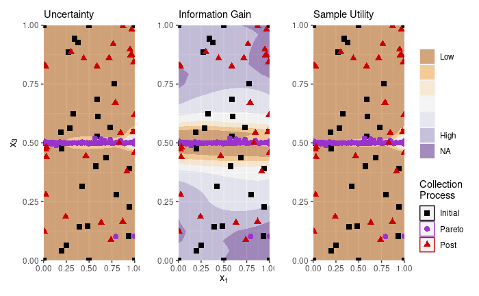

```r
g3 = ggplot() +
  geom_contour_filled(data = filter(fine.grid, x2 == GPar.new$x2, x3 != GPar.new$x3),
                      mapping = aes(x = x1, y = x3, z = info*(prob)*(1-prob), color = info*(prob)*(1-prob)),
                      bins = ncolor, alpha = 0.5)+
  geom_point(data = filter(GPar.all, x1 <= upper[1], x1 >= lower[1], x2 <= upper[2], x2 >= lower[2], order == 0),
             mapping = aes(x = x1, y = x3, color = 'initial', shape = 'initial'), size = pt.size) +
  geom_point(data = filter(GPar.all, x1 <= upper[1], x1 >= lower[1], x2 <= upper[2], x2 >= lower[2],
                           order > 0, order < Pareto.budget+1),
             mapping = aes(x = x1, y = x3, color = 'Pareto', shape = 'Pareto'), size = pt.size) +
  geom_point(data = filter(GPar.all, order > Pareto.budget),
             mapping = aes(x = x1, y = x3, color = 'Post', shape = 'Post'), size = pt.size) +
  scale_fill_brewer(labels = c("Low", rep("", ncolor-3), "High"), palette = "PuOr")  +
  scale_color_manual(values = c('initial' = 'black', 'Pareto' = 'darkorchid3', 'Post' = 'red3'),
                     labels = c('Initial', 'Pareto', 'Post'), breaks = c('initial', 'Pareto', 'Post')) +
  scale_shape_manual(values = c('initial' = 15, 'Pareto' = 16, 'Post' = 17),
                     labels = c('Initial', 'Pareto', 'Post'), breaks = c('initial', 'Pareto', 'Post')) +
  labs(x = "", y = "", subtitle = "Sample Utility", fill = "",
       shape = 'Collection\nProcess', color = 'Collection\nProcess') +
  scale_x_continuous(expand = c(0, 0)) + scale_y_continuous(expand = c(0, 0)) +
  guides(color=guide_legend(override.aes=list(fill=NA))) # Remove fill in the legend

g1 + g2 + g3
```

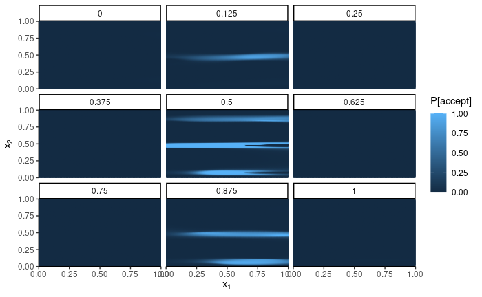

```r
# x3 slices
sz.fine = 100
x1.rng = seq(from = 0, to = 1, length.out = sz.fine)
x2.rng = seq(from = 0, to = 1, length.out = sz.fine)
x3.rng = seq(from = 0, to = 1, length.out = 9) # Simple slice for visualization
fine.grid = expand.grid(x1.rng, x2.rng, x3.rng)
fine.grid = fine.grid[,1:3]
names(fine.grid) = c('x1', 'x2', 'x3')

# Calculate
res = predict(object = mod.rad, newdata = fine.grid, type = "UK")
fine.grid$rad.mean = res$mean
fine.grid$rad.sd = res$sd
res = predict(object = mod.ang, newdata = data.frame(x1 = fine.grid$x1,
                      x2 = fine.grid$x2, x3 = fine.grid$x3), type = "UK")
fine.grid$ang.mean = res$mean
fine.grid$ang.sd = res$sd
# Uncertainty = P(success)*(1 - P(success))
fine.grid$prob = pnorm(q = 0, mean = fine.grid$rad.mean - 2, sd = fine.grid$rad.sd) *
  (1 - pnorm(q = 0, mean = fine.grid$ang.mean - 20, sd = fine.grid$ang.sd))

ggplot() +
  geom_point(data = fine.grid, mapping = aes(x = x1, y = x2, color = prob)) +
  labs(x = expression('x'[1]), y = expression('x'[2]), color = expression('P[accept]')) +
  theme_classic() + facet_wrap(~x3) +
  scale_x_continuous(expand = c(0, 0)) + scale_y_continuous(expand = c(0, 0))
```

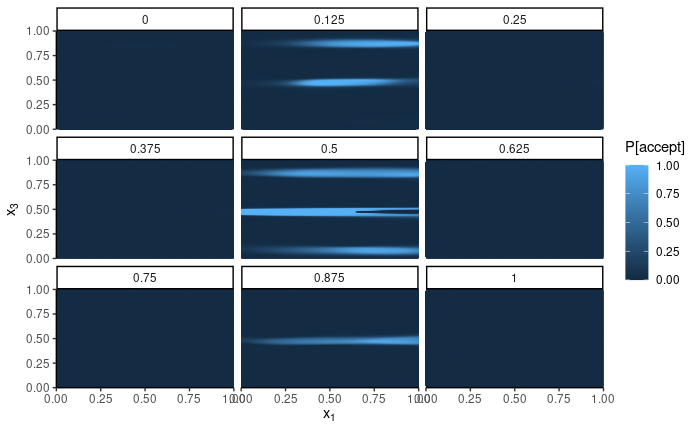

```r
# x2 slices
sz.fine = 100
x1.rng = seq(from = 0, to = 1, length.out = sz.fine)
x3.rng = seq(from = 0, to = 1, length.out = sz.fine)
x2.rng = seq(from = 0, to = 1, length.out = 9) # Simple slice for visualization
fine.grid = expand.grid(x1.rng, x2.rng, x3.rng)
fine.grid = fine.grid[,1:3]
names(fine.grid) = c('x1', 'x2', 'x3')

# Calculate
res = predict(object = mod.rad, newdata = fine.grid, type = "UK")
fine.grid$rad.mean = res$mean
fine.grid$rad.sd = res$sd
res = predict(object = mod.ang, newdata = data.frame(x1 = fine.grid$x1,
                      x2 = fine.grid$x2, x3 = fine.grid$x3), type = "UK")
fine.grid$ang.mean = res$mean
fine.grid$ang.sd = res$sd
# Uncertainty = P(success)*(1 - P(success))
fine.grid$prob = pnorm(q = 0, mean = fine.grid$rad.mean - 2, sd = fine.grid$rad.sd) *
  (1 - pnorm(q = 0, mean = fine.grid$ang.mean - 20, sd = fine.grid$ang.sd))

ggplot() +
  geom_point(data = fine.grid, mapping = aes(x = x1, y = x3, color = prob)) +
  labs(x = expression('x'[1]), y = expression('x'[3]), color = expression('P[accept]')) +
  theme_classic() + facet_wrap(~x2) +
  scale_x_continuous(expand = c(0, 0)) + scale_y_continuous(expand = c(0, 0))
```

```r
rm(g1, g2, g3, fine.grid, res)
```

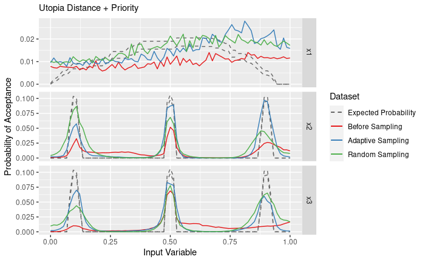

```r
# Load data: compare before/after refinement and with a random sampling for the refinement
GPar.start = read.csv(file = 'GPar_all_start.csv')
GPar.adapt = read.csv(file = 'GPar_Accept_Threshold.csv')
GPar.front = read.csv(file = 'GPar_fnt_start.csv')

# Compare to a random sample set
nsamp = nrow(GPar.adapt) - nrow(GPar.start)
GPar.rando = data.frame(x1 = runif(n = nsamp, min = 0, max = 1),
                        x2 = runif(n = nsamp, min = 0, max = 1),
                        x3 = runif(n = nsamp, min = 0, max = 1))
res = ZDT4.mod(x = as.matrix(GPar.rando))
GPar.rando$f1 = res[,1]; GPar.rando$f2 = res[,2]
# Fill in the remaining calculations: normalized outputs, distance, theta, order
GPar.rando = n.obj(GPar.data = GPar.rando, GPar.front = GPar.front)
cl <- makeCluster(2)
registerDoParallel(cl)
dist = foreach(row = 1:nrow(GPar.rando)) %dopar%
  n.dist(f1.norm = GPar.rando$f1.norm[row], f2.norm = GPar.rando$f2.norm[row], GPar.front = GPar.front)
stopCluster(cl)
GPar.rando$dist = unlist(dist)
GPar.rando$theta = atan(GPar.rando$f2.norm/GPar.rando$f1.norm)*180/pi*10/9
GPar.rando$order = seq(from = max(GPar.start$order) + 1, to = max(GPar.start$order) + nsamp, by = 1)
GPar.rando = rbind(GPar.start[, names(GPar.start) %in% names(GPar.rando)], GPar.rando)

# Add the $rad calculations
GPar.start$rad = sqrt(GPar.start$f1.norm^2 + GPar.start$f2.norm^2)
GPar.adapt$rad = sqrt(GPar.adapt$f1.norm^2 + GPar.adapt$f2.norm^2)
GPar.rando$rad = sqrt(GPar.rando$f1.norm^2 + GPar.rando$f2.norm^2)

# Use the final GP model with the full dataset
mod.rad.start = fill.sample.mod(GPar.data = GPar.start, input.name = c('x1', 'x2', 'x3'), output.name = 'rad')
mod.ang.start = fill.sample.mod(GPar.data = GPar.start, input.name = c('x1', 'x2', 'x3'), output.name = 'theta')

mod.rad.adapt = fill.sample.mod(GPar.data = GPar.adapt, input.name = c('x1', 'x2', 'x3'), output.name = 'rad')
mod.ang.adapt = fill.sample.mod(GPar.data = GPar.adapt, input.name = c('x1', 'x2', 'x3'), output.name = 'theta')

mod.rad.rando = fill.sample.mod(GPar.data = GPar.rando, input.name = c('x1', 'x2', 'x3'), output.name = 'rad')
mod.ang.rando = fill.sample.mod(GPar.data = GPar.rando, input.name = c('x1', 'x2', 'x3'), output.name = 'theta')

# Obtain marginalized probabilities with a fine resolution grid (50 points). Calculate the integral with a Monte Carlo sampling of 1500 samples each.
Infer.radan.start = marginal.rad(mod.rad.start, mod.ang.start)
Infer.radan.adapt = marginal.rad(mod.rad.adapt, mod.ang.adapt)
Infer.radan.rando = marginal.rad(mod.rad.rando, mod.ang.rando)

# Compare to true marginal
radan.tru = read.csv('ExpectedMarginal_radan.csv')

ggplot() +
  geom_path(data = radan.tru,        mapping = aes(x = x, y = prob+psd, color = 'tru'), linetype = 2) +
  geom_path(data = radan.tru,        mapping = aes(x = x, y = prob-psd, color = 'tru'), linetype = 2) +
  geom_path(data = Infer.radan.start, mapping = aes(x = x, y = prob, color = 'start')) +
  geom_path(data = Infer.radan.adapt, mapping = aes(x = x, y = prob, color = 'adapt')) +
  geom_path(data = Infer.radan.rando, mapping = aes(x = x, y = prob, color = 'rando')) +
  facet_grid(var~., scales = 'free_y') +
  labs(x = 'Input Variable', y = 'Probability of Acceptance', subtitle = 'Utopia Distance + Priority',
       color = 'Dataset') +
  scale_color_manual(labels = c('tru' = 'Expected Probability',
                                  'start' = 'Before Sampling',
                                  'adapt' = 'Adaptive Sampling', 'rando' = 'Random Sampling'),
                       values = c('tru' = 'grey40', 'start' = '#e41a1c', 'adapt' = '#377eb8', 'rando' = '#4daf4a'),
                       breaks = c('tru', 'start', 'adapt', 'rando')) +
  guides(color = guide_legend(override.aes = list(linetype = c(2, 1, 1, 1))))
```

```r
# Coefficients of determination.
expect1 = filter(radan.tru, var == 'x1')$prob
expect2 = filter(radan.tru, var == 'x2')$prob
expect3 = filter(radan.tru, var == 'x3')$prob
data.frame(method = c('Before Sampling', 'Adaptive Sampling', 'Random Sampling'),
           R2.x1 = c(cor(x = filter(Infer.radan.start, var == 'x1')$prob, y = expect1, method = 'pearson')^2,
             cor(x = filter(Infer.radan.adapt, var == 'x1')$prob, y = expect1, method = 'pearson')^2,
             cor(x = filter(Infer.radan.rando, var == 'x1')$prob, y = expect1, method = 'pearson')^2),
           R2.x2 = c(cor(x = filter(Infer.radan.start, var == 'x2')$prob, y = expect2, method = 'pearson')^2,
             cor(x = filter(Infer.radan.adapt, var == 'x2')$prob, y = expect2, method = 'pearson')^2,
             cor(x = filter(Infer.radan.rando, var == 'x2')$prob, y = expect2, method = 'pearson')^2),
           R2.x3 = c(cor(x = filter(Infer.radan.start, var == 'x3')$prob, y = expect3, method = 'pearson')^2,
             cor(x = filter(Infer.radan.adapt, var == 'x3')$prob, y = expect3, method = 'pearson')^2,
             cor(x = filter(Infer.radan.rando, var == 'x3')$prob, y = expect3, method = 'pearson')^2)
           )
```

| method | R2.x1 | R2.x2 | R2.x3 |
| --- | --- | --- | --- |
| Before Sampling | 0.0009820573 | 0.6464695 | 0.3081697 |
| Adaptive Sampling | 0.0061626047 | 0.7961334 | 0.7786800 |
| Random Sampling | 0.1609677661 | 0.6658822 | 0.6483443 |

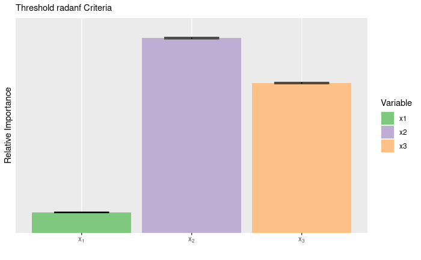

```r
# Relative importance: inverse of the area under the curve, normalized units,
# adjusted by the range of the probabilities' means
Infer.x1 = filter(Infer.radan.adapt, var == 'x1')
Infer.x2 = filter(Infer.radan.adapt, var == 'x2')
Infer.x3 = filter(Infer.radan.adapt, var == 'x3')
Import.radan = data.frame(import = c(diff(range(Infer.x1$prob))*nrow(Infer.x1)/sum(Infer.x1$psd),
                                     diff(range(Infer.x2$prob))*nrow(Infer.x2)/sum(Infer.x2$psd),
                                     diff(range(Infer.x3$prob))*nrow(Infer.x3)/sum(Infer.x3$psd)),
                          var = c('x1', 'x2', 'x3'),
                          typ = 'radan')
# Uncertainty in the calculation based on the Monte Carlo error
Import.radan$sd = sqrt(c(max(Infer.x1$prob)*(1-max(Infer.x1$prob)) + min(Infer.x1$prob)*(1-min(Infer.x1$prob)) *
                      diff(range(Infer.x1$prob)),
                    max(Infer.x2$prob)*(1-max(Infer.x2$prob)) + min(Infer.x2$prob)*(1-min(Infer.x2$prob)) *
                      diff(range(Infer.x2$prob)),
                    max(Infer.x3$prob)*(1-max(Infer.x3$prob)) + min(Infer.x3$prob)*(1-min(Infer.x3$prob)) *
                      diff(range(Infer.x3$prob)) )/1500 +
                  c(var(Infer.x1$psd), var(Infer.x2$psd), var(Infer.x3$psd))/nrow(Infer.x1) )

ggplot(Import.radan) +
  geom_col(mapping = aes(x = var, y = import, fill = var)) +
  geom_errorbar(mapping = aes(x = var, ymin = import - sd, ymax = import + sd), width = 0.5) +
  labs(x = '', y = 'Relative Importance', fill = 'Variable',
       subtitle = expression('Threshold radanf Criteria')) +
  scale_y_continuous(breaks = c(), expand = expansion(mult = c(0, .1))) +
  scale_x_discrete(labels = c(expression('x'[1]), expression('x'[2]), expression('x'[3]))) +
  scale_fill_manual(values = c('#7fc97f', '#beaed4', '#fdc086'))
```

```r
# Store the data for importance ranking comparison later
Infer.plt = rbind(Infer.x1, Infer.x2, Infer.x3);
radan.tru$cat = 'tru';          Infer.radan.start$cat = 'start'
Infer.radan.adapt$cat = 'adapt'; Infer.radan.rando$cat = 'rando'
write.csv(rbind(radan.tru[, names(radan.tru) %in% names(Infer.radan.start)],
      Infer.radan.start[, names(Infer.radan.start) %in% names(radan.tru)],
      Infer.radan.adapt[, names(Infer.radan.adapt) %in% names(radan.tru)],
      Infer.radan.rando[, names(Infer.radan.rando) %in% names(radan.tru)]), 'Marginals_radan_tru.csv')
```

## Comparison of selection criteria by their marginals

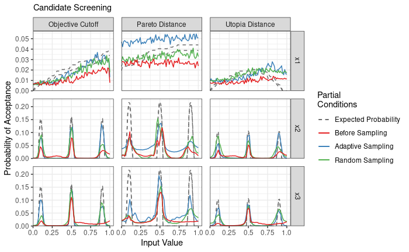

```r
Margin.del = read.csv(file = 'Marginals_delta_tru.csv')
Margin.cut = read.csv(file = 'Marginals_cutof_tru.csv')
Margin.rad = read.csv(file = 'Marginals_radan_tru.csv')

Margin.del$criteria = 'Pareto Distance'
Margin.cut$criteria = 'Objective Cutoff'
Margin.rad$criteria = 'Utopia Distance'

Margin = rbind(Margin.del, Margin.cut, Margin.rad)

ggplot() +
  geom_path(data = filter(Margin, cat == 'tru'), mapping = aes(x = x, y = prob + psd, color = cat), linetype = 2) +
  geom_path(data = filter(Margin, cat == 'tru'), mapping = aes(x = x, y = prob - psd, color = cat), linetype = 2) +
  geom_path(data = filter(Margin, cat != 'tru'), mapping = aes(x = x, y = prob, color = cat)) +
  facet_grid(var~criteria, scales = 'free_y') +
  labs(x = 'Input Value', y = 'Probability of Acceptance', subtitle = 'Candidate Screening',
       color = 'Partial\nConditions') +
  scale_y_continuous(expand = expansion(mult = c(0, 0.05))) +
  scale_x_continuous(expand = expansion(mult = c(0, 0.05)),
                     labels = c('0.0', '0.25', '0.5', '0.75', '1.0')) +
  theme_bw() + theme(panel.spacing = unit(0.7, "lines")) +
  scale_color_manual(labels = c('tru' = 'Expected Probability',
                                  'start' = 'Before Sampling',
                                  'adapt' = 'Adaptive Sampling', 'rando' = 'Random Sampling'),
                       values = c('tru' = 'grey40', 'start' = '#e41a1c', 'adapt' = '#377eb8', 'rando' = '#4daf4a'),
                       breaks = c('tru', 'start', 'adapt', 'rando')) +
  guides(color = guide_legend(override.aes = list(linetype = c(2, 1, 1, 1))))
```